# Youtube Likes prediction

**Author: Vincenzo Altomare**

**matr: 236028**

**Progetto di Data Mining A.A. 2021-2022**

# Introduzione

Youtube è una delle piattaforme di condivisione video più utilizzate al mondo, la quale mantiene un elenco dei video più di tendenza sulla piattaforma. Per determinare i video più di tendenza dell'anno, YouTube utilizza una combinazione di fattori tra cui la misurazione delle interazioni degli utenti, come numero di visualizzazioni, mi piace e commenti. Il dataset scelto racchiude una serie di video raccolti nell'arco di diversi mesi e lo scopo di questo lavoro è quello di predire il numero di like dei video tramite alcuni modelli di regressione.

Il dataset può essere reperito al seguente link: [Trending YouTube Video Statistics](https://www.kaggle.com/datasets/datasnaek/youtube-new)

# Pre-processing

In questa prima fase vengono importate alcune librerie che saranno utili allo scopo del progetto.

```python
import numpy as np
import warnings
warnings.simplefilter(action='ignore', category=FutureWarning)
warnings.filterwarnings("ignore", message="numpy.dtype size changed")
warnings.filterwarnings("ignore", message="numpy.ufunc size changed")
warnings.filterwarnings("ignore", message="numpy.ndarray size changed")
warnings.filterwarnings('ignore')
import pandas as pd
import seaborn as sns
from sklearn.preprocessing import MinMaxScaler, StandardScaler,RobustScaler
import matplotlib.pyplot as plt
from scipy.stats import skew,boxcox_normmax, boxcox
from scipy.special import boxcox1p
from sklearn.model_selection import GridSearchCV
```

Viene caricato e mostrato il dataset andando a reperire alcune semplici informazioni come il numero di righe e colonne che sono rispettivamente pari a 40949 e 16.

Per una migliore comprensione del processo di analisi e dei successivi, viene riportata una descrizione degli attributi:

- video_id: l'id del video
- trending_date: data in cui il video entra in tendenza
- title: titolo del video
- channel_title: titolo del canale che ha pubblicato il video
- category_id: numero intero che rappresenta una categoria
- publish_time: data di pubblicazione del video
- tags: parole e frasi per dare un contesto al video
- views: numero di visualizzazioni
- likes: numero di mi piace
- dislikes: numero di non mi piace
- comment_count: numero di commenti
- thumbnail_link: link alla copertina del video
- comments_disabled: indica se i commenti sono disabilitati o meno per un video
- ratings_disabled: indica se i giudizi sono disabilitati o meno per un video
- video_error_or_removed: indica se il video è stato rimosso
- description: descrizione del video

```python
df=pd.read_csv("../projectYT/data/USvideos.csv")
df.head()
```

|  | video_id | trending_date | title | channel_title | category_id | publish_time | tags | views | likes | dislikes | comment_count | thumbnail_link | comments_disabled | ratings_disabled | video_error_or_removed | description |
| --- | --- | --- | --- | --- | --- | --- | --- | --- | --- | --- | --- | --- | --- | --- | --- | --- |
| 0 | 2kyS6SvSYSE | 17.14.11 | WE WANT TO TALK ABOUT OUR MARRIAGE | CaseyNeistat | 22 | 2017-11-13T17:13:01.000Z | SHANtell martin | 748374 | 57527 | 2966 | 15954 | https://i.ytimg.com/vi/2kyS6SvSYSE/default.jpg | False | False | False | SHANTELL'S CHANNEL - https://www.youtube.com/s... |
| 1 | 1ZAPwfrtAFY | 17.14.11 | The Trump Presidency: Last Week Tonight with J... | LastWeekTonight | 24 | 2017-11-13T07:30:00.000Z | last week tonight trump presidency\|"last week ... | 2418783 | 97185 | 6146 | 12703 | https://i.ytimg.com/vi/1ZAPwfrtAFY/default.jpg | False | False | False | One year after the presidential election, John... |
| 2 | 5qpjK5DgCt4 | 17.14.11 | Racist Superman \| Rudy Mancuso, King Bach & Le... | Rudy Mancuso | 23 | 2017-11-12T19:05:24.000Z | racist superman\|"rudy"\|"mancuso"\|"king"\|"bach"... | 3191434 | 146033 | 5339 | 8181 | https://i.ytimg.com/vi/5qpjK5DgCt4/default.jpg | False | False | False | WATCH MY PREVIOUS VIDEO ▶ \n\nSUBSCRIBE ► http... |
| 3 | puqaWrEC7tY | 17.14.11 | Nickelback Lyrics: Real or Fake? | Good Mythical Morning | 24 | 2017-11-13T11:00:04.000Z | rhett and link\|"gmm"\|"good mythical morning"\|"... | 343168 | 10172 | 666 | 2146 | https://i.ytimg.com/vi/puqaWrEC7tY/default.jpg | False | False | False | Today we find out if Link is a Nickelback amat... |
| 4 | d380meD0W0M | 17.14.11 | I Dare You: GOING BALD!? | nigahiga | 24 | 2017-11-12T18:01:41.000Z | ryan\|"higa"\|"higatv"\|"nigahiga"\|"i dare you"\|"... | 2095731 | 132235 | 1989 | 17518 | https://i.ytimg.com/vi/d380meD0W0M/default.jpg | False | False | False | I know it's been a while since we did this sho... |

```python
df.shape
```

```
(40949, 16)
```

Attraverso la funzione info() si nota di come il dataset presenta 3/16 attributi bool, 5/16 int64 e 8/16 object

```python
df.info()
```

```
<class 'pandas.core.frame.DataFrame'>
RangeIndex: 40949 entries, 0 to 40948
Data columns (total 16 columns):
 #   Column                  Non-Null Count  Dtype
---  ------                  --------------  -----
 0   video_id                40949 non-null  object
 1   trending_date           40949 non-null  object
 2   title                   40949 non-null  object
 3   channel_title           40949 non-null  object
 4   category_id             40949 non-null  int64
 5   publish_time            40949 non-null  object
 6   tags                    40949 non-null  object
 7   views                   40949 non-null  int64
 8   likes                   40949 non-null  int64
 9   dislikes                40949 non-null  int64
 10  comment_count           40949 non-null  int64
 11  thumbnail_link          40949 non-null  object
 12  comments_disabled       40949 non-null  bool
 13  ratings_disabled        40949 non-null  bool
 14  video_error_or_removed  40949 non-null  bool
 15  description             40379 non-null  object
dtypes: bool(3), int64(5), object(8)
memory usage: 4.2+ MB
```

Si vanno ad eliminare i duplicati.

```python
df.duplicated().sum()
```

```
48
```

```python
df.drop_duplicates(inplace = True)
df.shape
```

```
(40901, 16)
```

Successivamente si analizzano i valori NaN presenti nel dataset, gli unici valori nulli sono presenti nell'attributo "description" e sono un numero abbastanza basso (569), pertanto si provvede ad eliminarli.

```python
df.isnull().sum()
```

```
video_id                    0
trending_date               0
title                       0
channel_title               0
category_id                 0
publish_time                0
tags                        0
views                       0
likes                       0
dislikes                    0
comment_count               0
thumbnail_link              0
comments_disabled           0
ratings_disabled            0
video_error_or_removed      0
description               569
dtype: int64
```

```python
df.dropna(inplace = True)
df.isnull().sum()
```

```
video_id                  0
trending_date             0
title                     0
channel_title             0
category_id               0
publish_time              0
tags                      0
views                     0
likes                     0
dislikes                  0
comment_count             0
thumbnail_link            0
comments_disabled         0
ratings_disabled          0
video_error_or_removed    0
description               0
dtype: int64
```

Si procede con l'analisi del campo "tags" dove si vuole andare a contare il numero dei tag inseriti nei video così da tenerli in considerazione nel processo di regressione. Come prima cosa si nota che ogni tag è separati dal successivo dal simbolo "|", pertanto c'è bisogno di splittare la stringa e successivamente andare a contare i singoli tag per ogni video, il cui numero è inserito nella colonna "no_tags"

```python
split = df['tags'].str.split('|')
tags_num = split.apply(lambda x : len(x))
df["no_tags"] = tags_num
df.head()
```

|  | video_id | trending_date | title | channel_title | category_id | publish_time | tags | views | likes | dislikes | comment_count | thumbnail_link | comments_disabled | ratings_disabled | video_error_or_removed | description | no_tags |
| --- | --- | --- | --- | --- | --- | --- | --- | --- | --- | --- | --- | --- | --- | --- | --- | --- | --- |
| 0 | 2kyS6SvSYSE | 17.14.11 | WE WANT TO TALK ABOUT OUR MARRIAGE | CaseyNeistat | 22 | 2017-11-13T17:13:01.000Z | SHANtell martin | 748374 | 57527 | 2966 | 15954 | https://i.ytimg.com/vi/2kyS6SvSYSE/default.jpg | False | False | False | SHANTELL'S CHANNEL - https://www.youtube.com/s... | 1 |
| 1 | 1ZAPwfrtAFY | 17.14.11 | The Trump Presidency: Last Week Tonight with J... | LastWeekTonight | 24 | 2017-11-13T07:30:00.000Z | last week tonight trump presidency\|"last week ... | 2418783 | 97185 | 6146 | 12703 | https://i.ytimg.com/vi/1ZAPwfrtAFY/default.jpg | False | False | False | One year after the presidential election, John... | 4 |
| 2 | 5qpjK5DgCt4 | 17.14.11 | Racist Superman \| Rudy Mancuso, King Bach & Le... | Rudy Mancuso | 23 | 2017-11-12T19:05:24.000Z | racist superman\|"rudy"\|"mancuso"\|"king"\|"bach"... | 3191434 | 146033 | 5339 | 8181 | https://i.ytimg.com/vi/5qpjK5DgCt4/default.jpg | False | False | False | WATCH MY PREVIOUS VIDEO ▶ \n\nSUBSCRIBE ► http... | 23 |
| 3 | puqaWrEC7tY | 17.14.11 | Nickelback Lyrics: Real or Fake? | Good Mythical Morning | 24 | 2017-11-13T11:00:04.000Z | rhett and link\|"gmm"\|"good mythical morning"\|"... | 343168 | 10172 | 666 | 2146 | https://i.ytimg.com/vi/puqaWrEC7tY/default.jpg | False | False | False | Today we find out if Link is a Nickelback amat... | 27 |
| 4 | d380meD0W0M | 17.14.11 | I Dare You: GOING BALD!? | nigahiga | 24 | 2017-11-12T18:01:41.000Z | ryan\|"higa"\|"higatv"\|"nigahiga"\|"i dare you"\|"... | 2095731 | 132235 | 1989 | 17518 | https://i.ytimg.com/vi/d380meD0W0M/default.jpg | False | False | False | I know it's been a while since we did this sho... | 14 |

Un passo successivo è quello di considerare anche la lunghezza del campo "description" che verrà inserita nella colonna "desc_length".

Si pensa che questi due attributi potranno tornare utili al processo di regressione per ottenere dei buoni risultati.

```python
df["desc_length"] = df["description"].apply (lambda x : len(x))
df.head()
```

|  | video_id | trending_date | title | channel_title | category_id | publish_time | tags | views | likes | dislikes | comment_count | thumbnail_link | comments_disabled | ratings_disabled | video_error_or_removed | description | no_tags | desc_length |
| --- | --- | --- | --- | --- | --- | --- | --- | --- | --- | --- | --- | --- | --- | --- | --- | --- | --- | --- |
| 0 | 2kyS6SvSYSE | 17.14.11 | WE WANT TO TALK ABOUT OUR MARRIAGE | CaseyNeistat | 22 | 2017-11-13T17:13:01.000Z | SHANtell martin | 748374 | 57527 | 2966 | 15954 | https://i.ytimg.com/vi/2kyS6SvSYSE/default.jpg | False | False | False | SHANTELL'S CHANNEL - https://www.youtube.com/s... | 1 | 1410 |
| 1 | 1ZAPwfrtAFY | 17.14.11 | The Trump Presidency: Last Week Tonight with J... | LastWeekTonight | 24 | 2017-11-13T07:30:00.000Z | last week tonight trump presidency\|"last week ... | 2418783 | 97185 | 6146 | 12703 | https://i.ytimg.com/vi/1ZAPwfrtAFY/default.jpg | False | False | False | One year after the presidential election, John... | 4 | 630 |
| 2 | 5qpjK5DgCt4 | 17.14.11 | Racist Superman \| Rudy Mancuso, King Bach & Le... | Rudy Mancuso | 23 | 2017-11-12T19:05:24.000Z | racist superman\|"rudy"\|"mancuso"\|"king"\|"bach"... | 3191434 | 146033 | 5339 | 8181 | https://i.ytimg.com/vi/5qpjK5DgCt4/default.jpg | False | False | False | WATCH MY PREVIOUS VIDEO ▶ \n\nSUBSCRIBE ► http... | 23 | 1177 |
| 3 | puqaWrEC7tY | 17.14.11 | Nickelback Lyrics: Real or Fake? | Good Mythical Morning | 24 | 2017-11-13T11:00:04.000Z | rhett and link\|"gmm"\|"good mythical morning"\|"... | 343168 | 10172 | 666 | 2146 | https://i.ytimg.com/vi/puqaWrEC7tY/default.jpg | False | False | False | Today we find out if Link is a Nickelback amat... | 27 | 1403 |
| 4 | d380meD0W0M | 17.14.11 | I Dare You: GOING BALD!? | nigahiga | 24 | 2017-11-12T18:01:41.000Z | ryan\|"higa"\|"higatv"\|"nigahiga"\|"i dare you"\|"... | 2095731 | 132235 | 1989 | 17518 | https://i.ytimg.com/vi/d380meD0W0M/default.jpg | False | False | False | I know it's been a while since we did this sho... | 14 | 636 |

```python
df['trending_date'] = pd.to_datetime(df['trending_date'], format='%y.%d.%m')
df['publish_time'] = pd.to_datetime(df['publish_time'], format='%Y-%m-%dT%H:%M:%S.%fZ')
df
```

|  | video_id | trending_date | title | channel_title | category_id | publish_time | tags | views | likes | dislikes | comment_count | thumbnail_link | comments_disabled | ratings_disabled | video_error_or_removed | description | no_tags | desc_length |
| --- | --- | --- | --- | --- | --- | --- | --- | --- | --- | --- | --- | --- | --- | --- | --- | --- | --- | --- |
| 0 | 2kyS6SvSYSE | 2017-11-14 | WE WANT TO TALK ABOUT OUR MARRIAGE | CaseyNeistat | 22 | 2017-11-13 17:13:01 | SHANtell martin | 748374 | 57527 | 2966 | 15954 | https://i.ytimg.com/vi/2kyS6SvSYSE/default.jpg | False | False | False | SHANTELL'S CHANNEL - https://www.youtube.com/s... | 1 | 1410 |
| 1 | 1ZAPwfrtAFY | 2017-11-14 | The Trump Presidency: Last Week Tonight with J... | LastWeekTonight | 24 | 2017-11-13 07:30:00 | last week tonight trump presidency\|"last week ... | 2418783 | 97185 | 6146 | 12703 | https://i.ytimg.com/vi/1ZAPwfrtAFY/default.jpg | False | False | False | One year after the presidential election, John... | 4 | 630 |
| 2 | 5qpjK5DgCt4 | 2017-11-14 | Racist Superman \| Rudy Mancuso, King Bach & Le... | Rudy Mancuso | 23 | 2017-11-12 19:05:24 | racist superman\|"rudy"\|"mancuso"\|"king"\|"bach"... | 3191434 | 146033 | 5339 | 8181 | https://i.ytimg.com/vi/5qpjK5DgCt4/default.jpg | False | False | False | WATCH MY PREVIOUS VIDEO ▶ \n\nSUBSCRIBE ► http... | 23 | 1177 |
| 3 | puqaWrEC7tY | 2017-11-14 | Nickelback Lyrics: Real or Fake? | Good Mythical Morning | 24 | 2017-11-13 11:00:04 | rhett and link\|"gmm"\|"good mythical morning"\|"... | 343168 | 10172 | 666 | 2146 | https://i.ytimg.com/vi/puqaWrEC7tY/default.jpg | False | False | False | Today we find out if Link is a Nickelback amat... | 27 | 1403 |
| 4 | d380meD0W0M | 2017-11-14 | I Dare You: GOING BALD!? | nigahiga | 24 | 2017-11-12 18:01:41 | ryan\|"higa"\|"higatv"\|"nigahiga"\|"i dare you"\|"... | 2095731 | 132235 | 1989 | 17518 | https://i.ytimg.com/vi/d380meD0W0M/default.jpg | False | False | False | I know it's been a while since we did this sho... | 14 | 636 |
| ... | ... | ... | ... | ... | ... | ... | ... | ... | ... | ... | ... | ... | ... | ... | ... | ... | ... | ... |
| 40943 | 1PhPYr_9zRY | 2018-06-14 | BTS Plays With Puppies While Answering Fan Que... | BuzzFeed Celeb | 22 | 2018-05-18 16:39:29 | BuzzFeed\|"BuzzFeedVideo"\|"Puppy Interview"\|"pu... | 8259128 | 645888 | 4052 | 62610 | https://i.ytimg.com/vi/1PhPYr_9zRY/default.jpg | False | False | False | BTS with the PPS, the puppies. These adorable ... | 27 | 926 |
| 40944 | BZt0qjTWNhw | 2018-06-14 | The Cat Who Caught the Laser | AaronsAnimals | 15 | 2018-05-18 13:00:04 | aarons animals\|"aarons"\|"animals"\|"cat"\|"cats"... | 1685609 | 38160 | 1385 | 2657 | https://i.ytimg.com/vi/BZt0qjTWNhw/default.jpg | False | False | False | The Cat Who Caught the Laser - Aaron's Animals | 14 | 46 |
| 40946 | D6Oy4LfoqsU | 2018-06-14 | I GAVE SAFIYA NYGAARD A PERFECT HAIR MAKEOVER ... | Brad Mondo | 24 | 2018-05-18 17:34:22 | I gave safiya nygaard a perfect hair makeover ... | 1066451 | 48068 | 1032 | 3992 | https://i.ytimg.com/vi/D6Oy4LfoqsU/default.jpg | False | False | False | I had so much fun transforming Safiyas hair in... | 24 | 775 |
| 40947 | oV0zkMe1K8s | 2018-06-14 | How Black Panther Should Have Ended | How It Should Have Ended | 1 | 2018-05-17 17:00:04 | Black Panther\|"HISHE"\|"Marvel"\|"Infinity War"\|... | 5660813 | 192957 | 2846 | 13088 | https://i.ytimg.com/vi/oV0zkMe1K8s/default.jpg | False | False | False | How Black Panther Should Have EndedWatch More ... | 22 | 3268 |
| 40948 | ooyjaVdt-jA | 2018-06-14 | Official Call of Duty®: Black Ops 4 — Multipla... | Call of Duty | 20 | 2018-05-17 17:09:38 | call of duty\|"cod"\|"activision"\|"Black Ops 4" | 10306119 | 357079 | 212976 | 144795 | https://i.ytimg.com/vi/ooyjaVdt-jA/default.jpg | False | False | False | Call of Duty: Black Ops 4 Multiplayer raises t... | 4 | 709 |

40332 rows × 18 columns

L'atributo "trending_days_difference" viene aggiunto al dataset con lo scopo di vedere entro quanto tempo ogni video entra in tendenza, i video che entrano in breve tempo in tendenza sicuramente avranno un maggiore aumento di interazioni da parte degli utenti.

```python
df['trending days_difference']=df.apply(lambda row: (row.trending_date-row.publish_time).days, axis = 1)
df['trending days_difference'].replace({-1:0},inplace=True)
df.head()
```

|  | video_id | trending_date | title | channel_title | category_id | publish_time | tags | views | likes | dislikes | comment_count | thumbnail_link | comments_disabled | ratings_disabled | video_error_or_removed | description | no_tags | desc_length | trending days_difference |
| --- | --- | --- | --- | --- | --- | --- | --- | --- | --- | --- | --- | --- | --- | --- | --- | --- | --- | --- | --- |
| 0 | 2kyS6SvSYSE | 2017-11-14 | WE WANT TO TALK ABOUT OUR MARRIAGE | CaseyNeistat | 22 | 2017-11-13 17:13:01 | SHANtell martin | 748374 | 57527 | 2966 | 15954 | https://i.ytimg.com/vi/2kyS6SvSYSE/default.jpg | False | False | False | SHANTELL'S CHANNEL - https://www.youtube.com/s... | 1 | 1410 | 0 |
| 1 | 1ZAPwfrtAFY | 2017-11-14 | The Trump Presidency: Last Week Tonight with J... | LastWeekTonight | 24 | 2017-11-13 07:30:00 | last week tonight trump presidency\|"last week ... | 2418783 | 97185 | 6146 | 12703 | https://i.ytimg.com/vi/1ZAPwfrtAFY/default.jpg | False | False | False | One year after the presidential election, John... | 4 | 630 | 0 |
| 2 | 5qpjK5DgCt4 | 2017-11-14 | Racist Superman \| Rudy Mancuso, King Bach & Le... | Rudy Mancuso | 23 | 2017-11-12 19:05:24 | racist superman\|"rudy"\|"mancuso"\|"king"\|"bach"... | 3191434 | 146033 | 5339 | 8181 | https://i.ytimg.com/vi/5qpjK5DgCt4/default.jpg | False | False | False | WATCH MY PREVIOUS VIDEO ▶ \n\nSUBSCRIBE ► http... | 23 | 1177 | 1 |
| 3 | puqaWrEC7tY | 2017-11-14 | Nickelback Lyrics: Real or Fake? | Good Mythical Morning | 24 | 2017-11-13 11:00:04 | rhett and link\|"gmm"\|"good mythical morning"\|"... | 343168 | 10172 | 666 | 2146 | https://i.ytimg.com/vi/puqaWrEC7tY/default.jpg | False | False | False | Today we find out if Link is a Nickelback amat... | 27 | 1403 | 0 |
| 4 | d380meD0W0M | 2017-11-14 | I Dare You: GOING BALD!? | nigahiga | 24 | 2017-11-12 18:01:41 | ryan\|"higa"\|"higatv"\|"nigahiga"\|"i dare you"\|"... | 2095731 | 132235 | 1989 | 17518 | https://i.ytimg.com/vi/d380meD0W0M/default.jpg | False | False | False | I know it's been a while since we did this sho... | 14 | 636 | 1 |

Viene mostrata una descrizione delle statistiche del dataset.

```python
df.describe()
```

|  | category_id | views | likes | dislikes | comment_count | no_tags | desc_length | trending days_difference |
| --- | --- | --- | --- | --- | --- | --- | --- | --- |
| count | 40332.000000 | 4.033200e+04 | 4.033200e+04 | 4.033200e+04 | 4.033200e+04 | 40332.000000 | 40332.000000 | 40332.000000 |
| mean | 19.942552 | 2.370824e+06 | 7.462234e+04 | 3.508185e+03 | 8.289092e+03 | 19.926659 | 1045.881831 | 14.656551 |
| std | 7.595933 | 7.432121e+06 | 2.297311e+05 | 2.318773e+04 | 3.433488e+04 | 11.947231 | 852.053649 | 138.666249 |
| min | 1.000000 | 5.490000e+02 | 0.000000e+00 | 0.000000e+00 | 0.000000e+00 | 1.000000 | 1.000000 | 0.000000 |
| 25% | 17.000000 | 2.466670e+05 | 5.615500e+03 | 2.040000e+02 | 6.230000e+02 | 10.000000 | 435.000000 | 2.000000 |
| 50% | 24.000000 | 6.884230e+05 | 1.835150e+04 | 6.360000e+02 | 1.873000e+03 | 19.000000 | 842.000000 | 4.000000 |
| 75% | 25.000000 | 1.832174e+06 | 5.563025e+04 | 1.945250e+03 | 5.785000e+03 | 29.000000 | 1394.000000 | 8.000000 |
| max | 43.000000 | 2.252119e+08 | 5.613827e+06 | 1.643059e+06 | 1.228655e+06 | 69.000000 | 5123.000000 | 4214.000000 |

Successivamente si sceglie di andare a rimuovere i video che impiegano più di 15 giorni ad entrare in tendenza, tenendo in considerazione che la media è di 14.65 giorni. Questo perchè video "più vecchi" potrebbero influenzare negativamente, poichè potrebbero essere diverse le cause sociali, che ne scaturiscono l'improvviso ingresso in tendenza e relativo aumento di statistiche.

Ci siano 2201 video che entrano in tendenza dopo i 15 giorni, dunque verranno eliminati.

```python
diff = df.loc[df['trending days_difference']>15]
diff.shape
```

```
(2201, 19)
```

```python
df = df.drop(df[(df['trending days_difference']>15)].index)
```

```python
df.dtypes
```

```
video_id                            object
trending_date               datetime64[ns]
title                               object
channel_title                       object
category_id                          int64
publish_time                datetime64[ns]
tags                                object
views                                int64
likes                                int64
dislikes                             int64
comment_count                        int64
thumbnail_link                      object
comments_disabled                     bool
ratings_disabled                      bool
video_error_or_removed                bool
description                         object
no_tags                              int64
desc_length                          int64
trending days_difference             int64
dtype: object
```

Vengono eliminate anche le colonne "video_id" e "thumbnail_link" giudicate poco rilevanti ai fini del test.

```python
df.drop(['video_id','thumbnail_link'],axis=1,inplace=True)
```

Si procede con un'analisi su alcune caratteristiche del dataset. In particolare viene mostrato il numero dei video entrati in tendenza presenti nel dataset, il quale contiene video degli anni 2018 e 2017.

circa 28000 video del dataset sono stati pubblicati nel 2018 mentre circa 10000 nel 2017

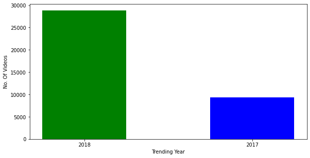

```python
day=df['trending_date'].dt.strftime ('%Y')
my_dict=(day.value_counts()).to_dict()
count= pd.DataFrame(list(my_dict.items()),columns = ['Trending year','No. Of Videos'])
fig=plt.figure(figsize=(10,5))
plt.bar(count['Trending year'],count['No. Of Videos'],color=['green', 'blue'],width=0.5)
plt.xlabel("Trending Year")
plt.ylabel("No. Of Videos")
plt.show()
```

Si vuole porre l'attenzione sui giorni in cui vengono pubblicati i video, la maggior parte dei video viene pubblicata durante la settimana, mentre nel week-end il numero cala. Questo è dovuto al fatto che nei week-end si tende a stare di meno a casa e ci si concentra su altre attività.

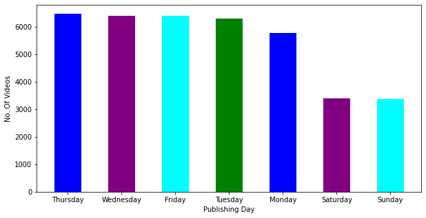

```
Thursday     6476
Wednesday    6410
Friday       6400
Tuesday      6301
Monday       5769
Saturday     3394
Sunday       3381
Name: publish_time, dtype: int64
```

```python
day=df['publish_time'].dt.day_name()
my_dict=(day.value_counts()).to_dict()
count= pd.DataFrame(list(my_dict.items()),columns = ['Publishing Day','No. Of Videos'])
fig=plt.figure(figsize=(10,5))
plt.bar(count['Publishing Day'],count['No. Of Videos'],color=['blue', 'purple', 'cyan', 'green'],width=0.5)
plt.xlabel("Publishing Day")
plt.ylabel("No. Of Videos")
plt.show()
print(day.value_counts())
```

Un altro fattore da tenere in considerazione sono gli orari in cui vengono pubblicati i video, si nota che vengono pubblicati principalmente nella fascia oraria 15:00-17:00. probabilmente perchè il target di riferimento dei video termina attività scolastiche/lavorative.

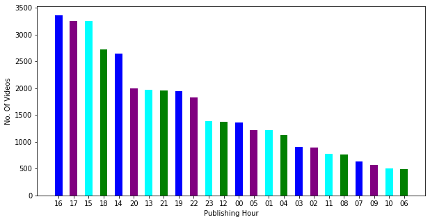

```
16    3358
17    3259
15    3250
18    2721
14    2644
20    1997
13    1963
21    1960
19    1938
22    1831
23    1385
12    1376
00    1365
05    1222
01    1217
04    1125
03     910
02     887
11     775
08     763
07     631
09     563
10     505
06     486
Name: publish_time, dtype: int64
```

```python
hour=df.publish_time.apply(lambda x: x.strftime("%H"))
my_dict=(hour.value_counts()).to_dict()
count= pd.DataFrame(list(my_dict.items()),columns = ['Publishing Hour','No. Of Videos'])
fig=plt.figure(figsize=(10,5))
plt.bar(count['Publishing Hour'],count['No. Of Videos'],color=['blue', 'purple', 'cyan', 'green'],width=0.5)
plt.xlabel("Publishing Hour")
plt.ylabel("No. Of Videos")
plt.show()
print(hour.value_counts())
```

Di seguito vengono rappresentate le colonne relative a "comments_disabled", "ratings_disabled", e "video_error_or_removed", le quali rappresentano dei casi particolari dove solo una piccola percentuale di vi video ricade e quindi verranno comunque prese in considerazione.

```
False    37549
True       582
Name: comments_disabled, dtype: int64
```

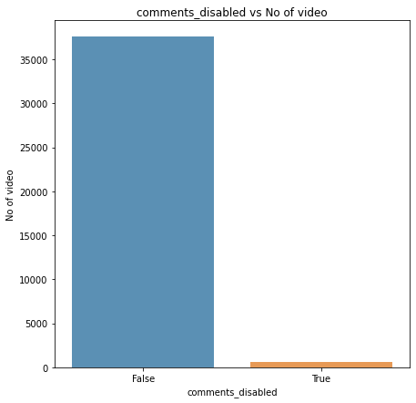

```
False    37970
True       161
Name: ratings_disabled, dtype: int64
```

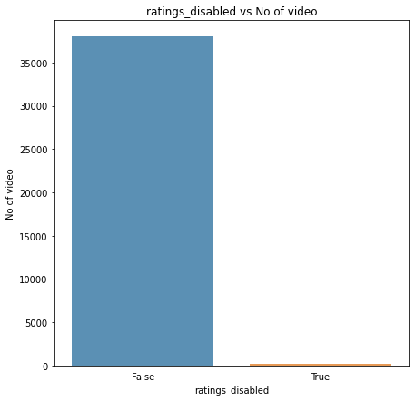

```
False    38110
True        21
Name: video_error_or_removed, dtype: int64
```

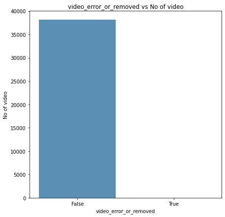

```python
for x in (['comments_disabled','ratings_disabled','video_error_or_removed']):
    count=df[x].value_counts()
    print(count)
    plt.figure(figsize=(7,7))
    sns.barplot(x=count.index, y=count.values, alpha=0.8)
    plt.title('{} vs No of video'.format(x))
    plt.ylabel('No of video')
    plt.xlabel('{}'.format(x))
    plt.show()
```

Di seguito viene riportato un mapping consigliato su kaggle per i nomi delle categorie rispettivamente alla colonna "category_id", a tale scopo viene introdotta un attributo "category_name" all'interno del dataset, il quale riporta i nomi delle categorie. Ciò sarà utile per una migliore comprensione delle categorie presenti.

```python
df['category_name'] = np.nan
df.loc[(df["category_id"] == 1),"category_name"] = 'Film and Animation'
df.loc[(df["category_id"] == 2),"category_name"] = 'Cars and Vehicles'
df.loc[(df["category_id"] == 10),"category_name"] = 'Music'
df.loc[(df["category_id"] == 15),"category_name"] = 'Pets and Animals'
df.loc[(df["category_id"] == 17),"category_name"] = 'Sport'
df.loc[(df["category_id"] == 19),"category_name"] = 'Travel and Events'
df.loc[(df["category_id"] == 20),"category_name"] = 'Gaming'
df.loc[(df["category_id"] == 22),"category_name"] = 'People and Blogs'
df.loc[(df["category_id"] == 23),"category_name"] = 'Comedy'
df.loc[(df["category_id"] == 24),"category_name"] = 'Entertainment'
df.loc[(df["category_id"] == 25),"category_name"] = 'News and Politics'
df.loc[(df["category_id"] == 26),"category_name"] = 'How to and Style'
df.loc[(df["category_id"] == 27),"category_name"] = 'Education'
df.loc[(df["category_id"] == 28),"category_name"] = 'Science and Technology'
df.loc[(df["category_id"] == 29),"category_name"] = 'Non Profits and Activism'
df.loc[(df["category_id"] == 43),"category_name"] = 'Shows'
```

La categoria che sembra prevalere è quella relativa all'intrattenimento seguita dalla categoria relativa alla musica.

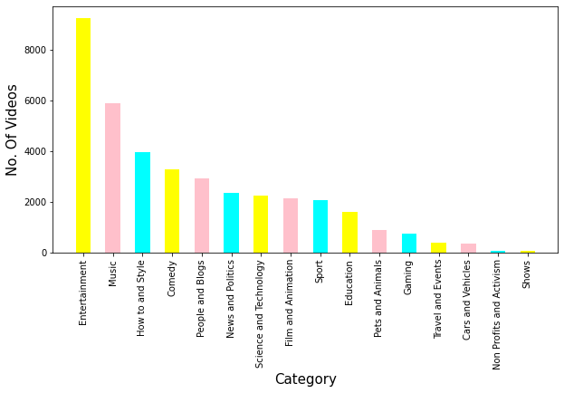

```python
my_dict=(df['category_name'].value_counts()).to_dict()
count= pd.DataFrame(list(my_dict.items()),columns = ['Category','No. Of Videos'])
fig=plt.figure(figsize=(10,5))
plt.bar(count['Category'],count['No. Of Videos'],color=['yellow', 'pink', 'cyan'],width=0.5)
plt.xticks(rotation=90)
plt.xlabel("Category",size=15)
plt.ylabel("No. Of Videos",size=15)
plt.show()
```

Si sceglie di considerare anche la lunghezza del titolo, poichè titoli brevi e concisi saranno di maggior rilievo per gli utenti. la media è di 48.78 caratteri. Viene aggiunta una nuova colonna: "title_length".

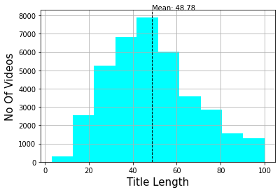

```python
df["title_length"]= df["title"].apply(lambda x: len(x))
ax=df['title_length'].hist(color="cyan")
ax.axvline(df['title_length'].mean(), color='k', linestyle='dashed', linewidth=1)
min_ylim, max_ylim = plt.ylim()
ax.text(df['title_length'].mean(), max_ylim, 'Mean: {:.2f}'.format(df['title_length'].mean()))
plt.xlabel("Title Length",fontsize=15)
plt.ylabel("No Of Videos",fontsize=15)
plt.show()
```

Vengono quindi analizzate alcune caratteristiche del titolo, che potrebbero attrarre maggiormente gli utenti, come il numero di lettere maiuscole e i careatteri speciali. Queste vengono rispettivamente memorizzate nelle colonne "Uppercase_count" e "special_char".

Si sceglie di non considerare il numero di lettere minuscole in quanto considerate poco utili ai fini del test.

```python
df['uppercase_count'] =  df['title'].str.count(r'[A-Z]')
df["special_char"] = df["title"].apply(lambda p: sum( not p.isalpha() for q in p ))
```

Viene anche aggiunta una colonna relativa al giorno e all'ora di pubblicazione dei video che, come già specificato precedentemente, potrebbero tornare utili.

```python
df['publish_day'] = df['publish_time'].dt.day_name()
df['publish_hour'] = df.publish_time.apply(lambda x: x.strftime("%H"))
df.head()
```

|  | trending_date | title | channel_title | category_id | publish_time | tags | views | likes | dislikes | comment_count | ... | description | no_tags | desc_length | trending days_difference | category_name | title_length | uppercase_count | special_char | publish_day | publish_hour |
| --- | --- | --- | --- | --- | --- | --- | --- | --- | --- | --- | --- | --- | --- | --- | --- | --- | --- | --- | --- | --- | --- |
| 0 | 2017-11-14 | WE WANT TO TALK ABOUT OUR MARRIAGE | CaseyNeistat | 22 | 2017-11-13 17:13:01 | SHANtell martin | 748374 | 57527 | 2966 | 15954 | ... | SHANTELL'S CHANNEL - https://www.youtube.com/s... | 1 | 1410 | 0 | People and Blogs | 34 | 28 | 34 | Monday | 17 |
| 1 | 2017-11-14 | The Trump Presidency: Last Week Tonight with J... | LastWeekTonight | 24 | 2017-11-13 07:30:00 | last week tonight trump presidency\|"last week ... | 2418783 | 97185 | 6146 | 12703 | ... | One year after the presidential election, John... | 4 | 630 | 0 | Entertainment | 62 | 11 | 62 | Monday | 07 |
| 2 | 2017-11-14 | Racist Superman \| Rudy Mancuso, King Bach & Le... | Rudy Mancuso | 23 | 2017-11-12 19:05:24 | racist superman\|"rudy"\|"mancuso"\|"king"\|"bach"... | 3191434 | 146033 | 5339 | 8181 | ... | WATCH MY PREVIOUS VIDEO ▶ \n\nSUBSCRIBE ► http... | 23 | 1177 | 1 | Comedy | 53 | 8 | 53 | Sunday | 19 |
| 3 | 2017-11-14 | Nickelback Lyrics: Real or Fake? | Good Mythical Morning | 24 | 2017-11-13 11:00:04 | rhett and link\|"gmm"\|"good mythical morning"\|"... | 343168 | 10172 | 666 | 2146 | ... | Today we find out if Link is a Nickelback amat... | 27 | 1403 | 0 | Entertainment | 32 | 4 | 32 | Monday | 11 |
| 4 | 2017-11-14 | I Dare You: GOING BALD!? | nigahiga | 24 | 2017-11-12 18:01:41 | ryan\|"higa"\|"higatv"\|"nigahiga"\|"i dare you"\|"... | 2095731 | 132235 | 1989 | 17518 | ... | I know it's been a while since we did this sho... | 14 | 636 | 1 | Entertainment | 24 | 12 | 24 | Sunday | 18 |

5 rows × 23 columns

```python
df.dtypes
```

```
trending_date               datetime64[ns]
title                               object
channel_title                       object
category_id                          int64
publish_time                datetime64[ns]
tags                                object
views                                int64
likes                                int64
dislikes                             int64
comment_count                        int64
comments_disabled                     bool
ratings_disabled                      bool
video_error_or_removed                bool
description                         object
no_tags                              int64
desc_length                          int64
trending days_difference             int64
category_name                       object
title_length                         int64
uppercase_count                      int64
special_char                         int64
publish_day                         object
publish_hour                        object
dtype: object
```

A seguire vengono visualizzati alcuni degli attributi numerici del dataset tramite dei boxplot, si vuole porre l'attenzione principalmente su "views", "likes", "dislikes" e "comment_count" i cui valori variano in un intervallo abbastanza largo e dispersivo.

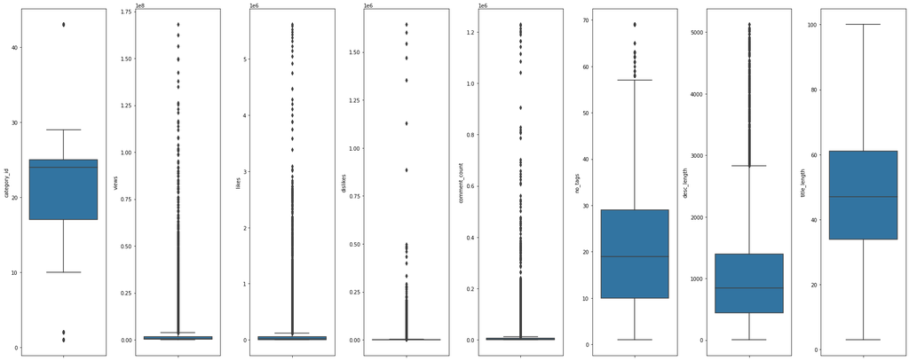

```python
features = ['category_id','views','likes','dislikes','comment_count','no_tags','desc_length','title_length']
plt.figure(figsize=(25, 10))
for i in range(0, len(features)):
    plt.subplot(1, 8, i+1)
    sns.boxplot(y=df[features[i]],orient='v')
    plt.tight_layout();
```

si vuole inoltre vedere come variano alcuni attributi numerici rispetto ai likes, si sceglie di droppare i video che superano i 10 milioni di views, in quanto solo in pochissimi riescono a raggiungere questi risultati e generalmente sono raggiunti da video musicali che vanno virali.

Si sceglie inoltre di droppare i video che superano i 70 mila dislike in quanto potrebbero essere soggetti ad alcuni fenomeni di hating non strettamente legati alla qualità del video, come c'era da aspettarsi si tendono ad avere pochi dislike e un grandissimo numero di like.

Per gli stessi motivi delle colonne "views" e "dislike" di sceglie di rimuovere i video che superano gli 800 mila commenti.

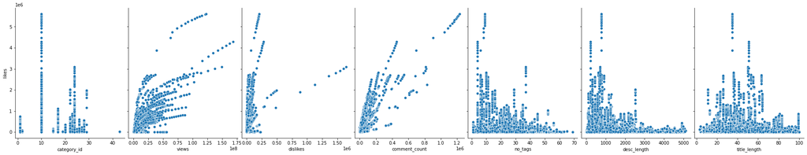

```python
plt.figure(figsize=(30,15))
sns.pairplot(data=df, x_vars=['category_id','views','dislikes','comment_count','no_tags','desc_length','title_length'], y_vars=['likes'], height=5, aspect=0.75);
fig.tight_layout();
```

```python
df = df.drop(df[(df['dislikes']>70000)].index)
df = df.drop(df[(df['comment_count']>800000)].index)
df = df.drop(df[(df['category_id']>30)].index)
df = df.drop(df[(df['views']>10000000)].index)

df.shape
```

```
(36573, 23)
```

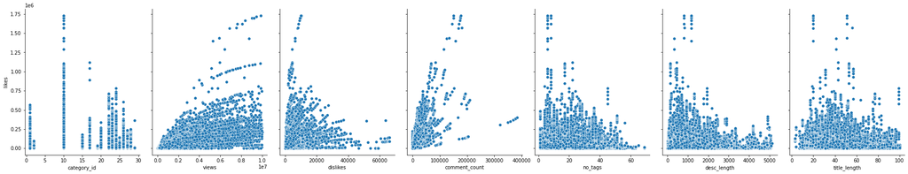

```python
plt.figure(figsize=(20,20))
sns.pairplot(data=df, x_vars=['category_id','views','dislikes','comment_count','no_tags','desc_length','title_length'], y_vars=['likes'], height=5, aspect=0.75);
fig.tight_layout();
```

Nuovamente una describe() sul dataset per avere una visione migliore degli attributi numerici.

```python
df.describe()
```

|  | category_id | views | likes | dislikes | comment_count | no_tags | desc_length | trending days_difference | title_length | uppercase_count | special_char |
| --- | --- | --- | --- | --- | --- | --- | --- | --- | --- | --- | --- |
| count | 36573.000000 | 3.657300e+04 | 3.657300e+04 | 36573.000000 | 36573.000000 | 36573.000000 | 36573.000000 | 36573.000000 | 36573.000000 | 36573.000000 | 36573.000000 |
| mean | 20.275969 | 1.210975e+06 | 4.311407e+04 | 1685.446039 | 4977.306292 | 20.027807 | 1048.470812 | 4.728898 | 48.891505 | 10.282394 | 48.876603 |
| std | 7.376386 | 1.601517e+06 | 8.072673e+04 | 3733.051287 | 12157.480925 | 11.899202 | 855.078174 | 3.597454 | 19.657023 | 8.857975 | 19.690890 |
| min | 1.000000 | 5.490000e+02 | 0.000000e+00 | 0.000000 | 0.000000 | 1.000000 | 3.000000 | 0.000000 | 3.000000 | 0.000000 | 0.000000 |
| 25% | 17.000000 | 2.287450e+05 | 5.191000e+03 | 189.000000 | 582.000000 | 10.000000 | 436.000000 | 2.000000 | 34.000000 | 5.000000 | 34.000000 |
| 50% | 24.000000 | 6.064460e+05 | 1.616000e+04 | 570.000000 | 1682.000000 | 19.000000 | 851.000000 | 4.000000 | 47.000000 | 8.000000 | 47.000000 |
| 75% | 25.000000 | 1.494215e+06 | 4.538600e+04 | 1591.000000 | 4721.000000 | 29.000000 | 1394.000000 | 7.000000 | 61.000000 | 12.000000 | 61.000000 |
| max | 29.000000 | 9.998724e+06 | 1.731826e+06 | 66251.000000 | 383762.000000 | 69.000000 | 5123.000000 | 15.000000 | 100.000000 | 77.000000 | 100.000000 |

Viene creato un nuovo dataset df_clean, poichè si sceglie di droppare alcuni attributi non più utili agli scopi dell'analisi, in quanto sono già stati estratti i dati necessari.

```python
df_clean = df.drop(['trending_date','description','title','tags','publish_time','channel_title'], axis=1)
```

Una visualizzazione del dataset df_clean.

```python
df_clean.head()
```

|  | category_id | views | likes | dislikes | comment_count | comments_disabled | ratings_disabled | video_error_or_removed | no_tags | desc_length | trending days_difference | category_name | title_length | uppercase_count | special_char | publish_day | publish_hour |
| --- | --- | --- | --- | --- | --- | --- | --- | --- | --- | --- | --- | --- | --- | --- | --- | --- | --- |
| 0 | 22 | 748374 | 57527 | 2966 | 15954 | False | False | False | 1 | 1410 | 0 | People and Blogs | 34 | 28 | 34 | Monday | 17 |
| 1 | 24 | 2418783 | 97185 | 6146 | 12703 | False | False | False | 4 | 630 | 0 | Entertainment | 62 | 11 | 62 | Monday | 07 |
| 2 | 23 | 3191434 | 146033 | 5339 | 8181 | False | False | False | 23 | 1177 | 1 | Comedy | 53 | 8 | 53 | Sunday | 19 |
| 3 | 24 | 343168 | 10172 | 666 | 2146 | False | False | False | 27 | 1403 | 0 | Entertainment | 32 | 4 | 32 | Monday | 11 |
| 4 | 24 | 2095731 | 132235 | 1989 | 17518 | False | False | False | 14 | 636 | 1 | Entertainment | 24 | 12 | 24 | Sunday | 18 |

Successivamente vengono mostrate le distribuzioni relative ad alcuni valori chiave quali "likes", "dislikes", "comment_count", "views".

Per quanto riguarda i likes, la maggior parte di essi si concentra in un intervallo che va da 0 a 250 mila, solo alcuni presentano dei valori molto elevati (1.75 milioni).

[output not shown]

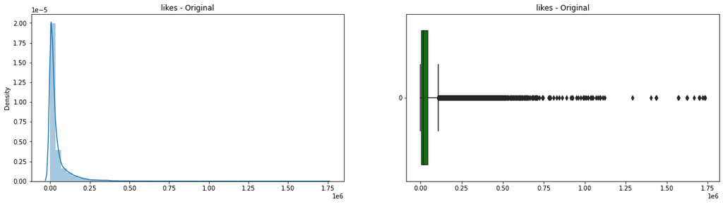

```python
f,ax = plt.subplots(1,2,figsize=(20,5))

g = sns.distplot(df_clean['likes'],kde=True, ax=ax[0])
ax[0].set_title('likes - Original')
ax[0].set_xlabel('')

g = sns.boxplot(data = df_clean['likes'],color='green',orient='h', ax=ax[1])
ax[1].set_title('likes - Original')
ax[1].set_xlabel('')
```

I dislike invece si concentrano maggiormente tra 0 e 10 mila.

[output not shown]

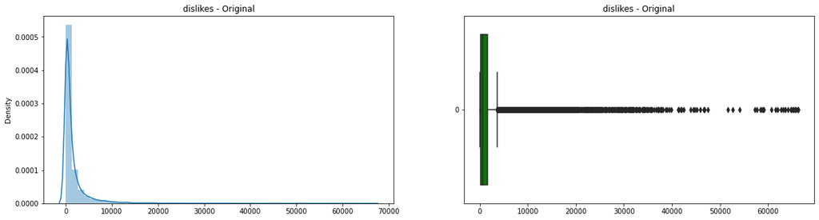

```python
f,ax = plt.subplots(1,2,figsize=(20,5))

g = sns.distplot(df_clean['dislikes'],kde=True, ax=ax[0])
ax[0].set_title('dislikes - Original')
ax[0].set_xlabel('')

g = sns.boxplot(data = df_clean['dislikes'],color='green',orient='h', ax=ax[1])
ax[1].set_title('dislikes - Original')
ax[1].set_xlabel('')
```

Il numero dei commenti invece si concentra tra 0 e 50000 mila.

[output not shown]

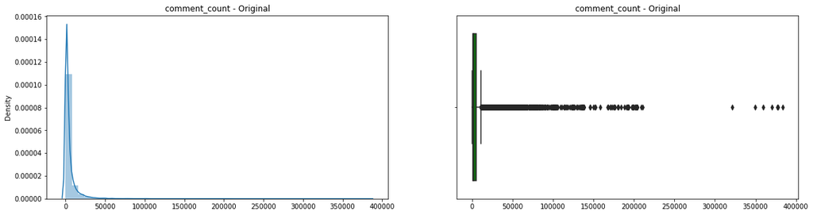

```python
f,ax = plt.subplots(1,2,figsize=(20,5))

g = sns.distplot(df_clean['comment_count'],kde=True, ax=ax[0])
ax[0].set_title('comment_count - Original')
ax[0].set_xlabel('')

g = sns.boxplot(df_clean['comment_count'],color='green',orient='h', ax=ax[1])
ax[1].set_title('comment_count - Original')
ax[1].set_xlabel('')
```

Le views si concentrano tra poco più di 0 e 4 milioni.

[output not shown]

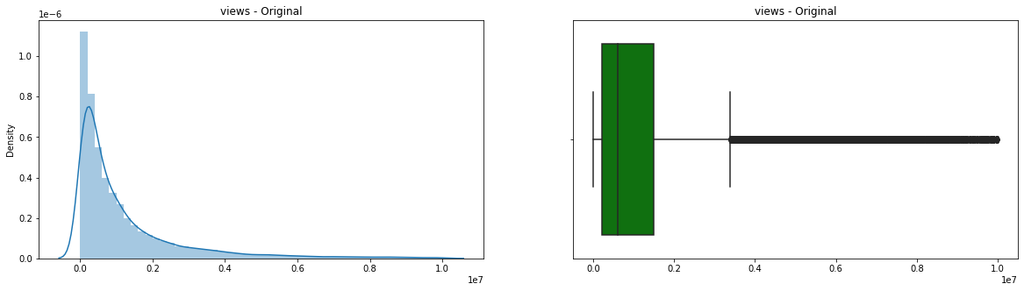

```python
f,ax = plt.subplots(1,2,figsize=(20,5))

g = sns.distplot(df_clean['views'],kde=True, ax=ax[0])
ax[0].set_title('views - Original')
ax[0].set_xlabel('')

g = sns.boxplot(df_clean['views'],color='green',orient='h', ax=ax[1])
ax[1].set_title('views - Original')
ax[1].set_xlabel('')
```

Tramite l'aiuto di un LabelEncoder si decide di trasformare le colonne "comments_disabled", "ratings_disabled", "video_error_or_removed".

```python
from sklearn.preprocessing import LabelEncoder
le = LabelEncoder()
for i in df_clean.columns:
    if i in ['comments_disabled','ratings_disabled','video_error_or_removed']:
        df_clean[i] = le.fit_transform(df_clean[i])
df_final = df_clean

df_final.head()
```

|  | category_id | views | likes | dislikes | comment_count | comments_disabled | ratings_disabled | video_error_or_removed | no_tags | desc_length | trending days_difference | category_name | title_length | uppercase_count | special_char | publish_day | publish_hour |
| --- | --- | --- | --- | --- | --- | --- | --- | --- | --- | --- | --- | --- | --- | --- | --- | --- | --- |
| 0 | 22 | 748374 | 57527 | 2966 | 15954 | 0 | 0 | 0 | 1 | 1410 | 0 | People and Blogs | 34 | 28 | 34 | Monday | 17 |
| 1 | 24 | 2418783 | 97185 | 6146 | 12703 | 0 | 0 | 0 | 4 | 630 | 0 | Entertainment | 62 | 11 | 62 | Monday | 07 |
| 2 | 23 | 3191434 | 146033 | 5339 | 8181 | 0 | 0 | 0 | 23 | 1177 | 1 | Comedy | 53 | 8 | 53 | Sunday | 19 |
| 3 | 24 | 343168 | 10172 | 666 | 2146 | 0 | 0 | 0 | 27 | 1403 | 0 | Entertainment | 32 | 4 | 32 | Monday | 11 |
| 4 | 24 | 2095731 | 132235 | 1989 | 17518 | 0 | 0 | 0 | 14 | 636 | 1 | Entertainment | 24 | 12 | 24 | Sunday | 18 |

C'è bisogno di modificare l'attributo "publish_hour" così da renderla di tipo int.

```python
df_final['publish_hour'] = df_final['publish_hour'].astype(str).astype(int)
```

```python
df_final.dtypes
```

```
category_id                  int64
views                        int64
likes                        int64
dislikes                     int64
comment_count                int64
comments_disabled            int64
ratings_disabled             int64
video_error_or_removed       int64
no_tags                      int64
desc_length                  int64
trending days_difference     int64
category_name               object
title_length                 int64
uppercase_count              int64
special_char                 int64
publish_day                 object
publish_hour                 int32
dtype: object
```

Si sceglie di droppare anche category_id.

```python
df_final.drop(['category_id'], axis = 1, inplace = True)
df_final.describe()
```

|  | views | likes | dislikes | comment_count | comments_disabled | ratings_disabled | video_error_or_removed | no_tags | desc_length | trending days_difference | title_length | uppercase_count | special_char | publish_hour |
| --- | --- | --- | --- | --- | --- | --- | --- | --- | --- | --- | --- | --- | --- | --- |
| count | 3.657300e+04 | 3.657300e+04 | 36573.000000 | 36573.000000 | 36573.000000 | 36573.000000 | 36573.000000 | 36573.000000 | 36573.000000 | 36573.000000 | 36573.000000 | 36573.000000 | 36573.000000 | 36573.000000 |
| mean | 1.210975e+06 | 4.311407e+04 | 1685.446039 | 4977.306292 | 0.015394 | 0.003855 | 0.000547 | 20.027807 | 1048.470812 | 4.728898 | 48.891505 | 10.282394 | 48.876603 | 13.805348 |
| std | 1.601517e+06 | 8.072673e+04 | 3733.051287 | 12157.480925 | 0.123115 | 0.061972 | 0.023379 | 11.899202 | 855.078174 | 3.597454 | 19.657023 | 8.857975 | 19.690890 | 6.442455 |
| min | 5.490000e+02 | 0.000000e+00 | 0.000000 | 0.000000 | 0.000000 | 0.000000 | 0.000000 | 1.000000 | 3.000000 | 0.000000 | 3.000000 | 0.000000 | 0.000000 | 0.000000 |
| 25% | 2.287450e+05 | 5.191000e+03 | 189.000000 | 582.000000 | 0.000000 | 0.000000 | 0.000000 | 10.000000 | 436.000000 | 2.000000 | 34.000000 | 5.000000 | 34.000000 | 11.000000 |
| 50% | 6.064460e+05 | 1.616000e+04 | 570.000000 | 1682.000000 | 0.000000 | 0.000000 | 0.000000 | 19.000000 | 851.000000 | 4.000000 | 47.000000 | 8.000000 | 47.000000 | 15.000000 |
| 75% | 1.494215e+06 | 4.538600e+04 | 1591.000000 | 4721.000000 | 0.000000 | 0.000000 | 0.000000 | 29.000000 | 1394.000000 | 7.000000 | 61.000000 | 12.000000 | 61.000000 | 18.000000 |
| max | 9.998724e+06 | 1.731826e+06 | 66251.000000 | 383762.000000 | 1.000000 | 1.000000 | 1.000000 | 69.000000 | 5123.000000 | 15.000000 | 100.000000 | 77.000000 | 100.000000 | 23.000000 |

Viene mostrata una matrice di correlazione relativa al dataset df_final, il che è utile per vedere come sono correlate le colonne del dataset, verificare se le supposizioni precedenti siano corrette o meno e prendere i dovuti provvedimenti. In particolare il coefficiente di correlazione indica la "potenza" della correlazione tra due variabili

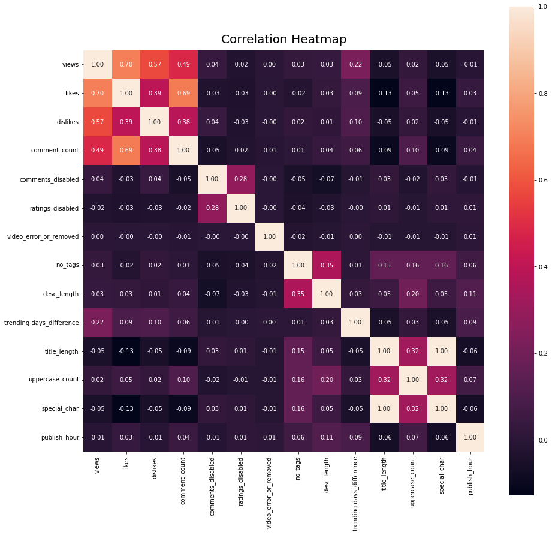

```python
corr = df_final.corr()
plt.figure(figsize=(15, 15))
heatmap = sns.heatmap(corr, annot=True, square = True, fmt='.2f')
heatmap.set_title('Correlation Heatmap', fontdict={'fontsize':20}, pad=12);
plt.show()
```

Si sposta l'attenzione verso le correlazioni che riguardano l'attributo target, ovvero "likes". Come si può notare vi è una forte correlazione con "views","comment_count" e "dislikes".

Per quanto riguarda gli attributi con una correlazione negativa essi indicano che all'aumentare di una, diminuisce l'altra e viceversa, nel caso in esame è una correlazione negativa debole.

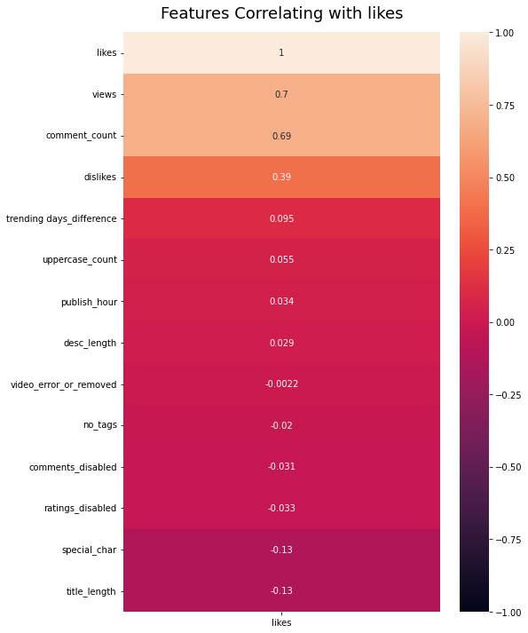

```python
corr[['likes']].sort_values(by='likes', ascending = False)
plt.figure(figsize=(8, 12))
heatmap = sns.heatmap(corr[['likes']].sort_values(by='likes', ascending=False), vmin=-1, vmax=1, annot=True)
heatmap.set_title('Features Correlating with likes', fontdict={'fontsize':18}, pad=16);
```

Si inizia a preparare i dati alla fase di addestramento dei modelli di machine learning. Vengono quindi generati due nuovi dataset, X_df (contiene gli attributi da utilizzare nel processo di regressione) ed y_df (contenente l'attributo target likes). Per prima cosa vengono selezionati gli attributi da utilizzare per costruire X_df, scegliendo di droppare, oltre all'attributo target "likes", gli attributi "video_error_or_removed", "publish_hour", "no_tags" e "uppercase_count", per via della debole correlazione con l'attributo target.

```python
X_df= df_final.drop(['likes','video_error_or_removed','publish_hour','no_tags','uppercase_count'], axis = 1)
y_df=df_final.likes
```

In questa sezione si vuole misurare la "skewness" degli attributi numerici presenti in X_df, dove per skewness è una misura dell'asimmetria di una distribuzione e dà informazioni sulla direzione degli outlier. Questo potrebbe essere utile per la scelta di alcuni scaler in fase di preprocessing.

Vengono considerati solo i valori di skewnes maggiori di 0.5. In particolare ratings_disabled e comment_count presenzano alti valori positivi, per cui la maggior parte dei valori è raggruppata verso sinistra, mentre la parte destra è più lunga.

```python
from scipy.stats import skew

df_all_num = X_df.select_dtypes(include=['int64','float64'])
skew_features = df_all_num.apply(lambda x: skew(x)).sort_values(ascending=False)
high_skew = skew_features[skew_features > 0.5]
skew_index = high_skew.index
skewness = pd.DataFrame({'Skew' :high_skew})
skew_features
```

```
ratings_disabled            16.012084
comment_count               11.174931
comments_disabled            7.872519
dislikes                     7.044686
views                        2.493414
desc_length                  1.627611
trending days_difference     0.881782
title_length                 0.455782
special_char                 0.443952
dtype: float64
```

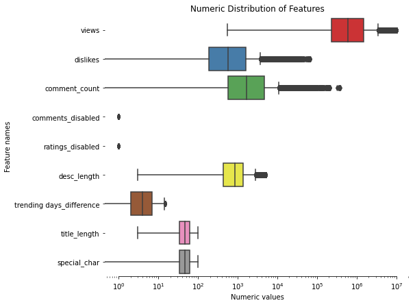

```python
f, ax = plt.subplots(figsize=(8, 7))
ax.set_xscale("log")
ax = sns.boxplot(data=df_all_num , orient="h", palette="Set1")
ax.xaxis.grid(False)
ax.set(ylabel="Feature names")
ax.set(xlabel="Numeric values")
ax.set(title="Numeric Distribution of Features")
sns.despine(trim=True, left=True)
```

describe() sul dataset X_df.

```python
X_df.describe()
```

|  | views | dislikes | comment_count | comments_disabled | ratings_disabled | desc_length | trending days_difference | title_length | special_char |
| --- | --- | --- | --- | --- | --- | --- | --- | --- | --- |
| count | 3.657300e+04 | 36573.000000 | 36573.000000 | 36573.000000 | 36573.000000 | 36573.000000 | 36573.000000 | 36573.000000 | 36573.000000 |
| mean | 1.210975e+06 | 1685.446039 | 4977.306292 | 0.015394 | 0.003855 | 1048.470812 | 4.728898 | 48.891505 | 48.876603 |
| std | 1.601517e+06 | 3733.051287 | 12157.480925 | 0.123115 | 0.061972 | 855.078174 | 3.597454 | 19.657023 | 19.690890 |
| min | 5.490000e+02 | 0.000000 | 0.000000 | 0.000000 | 0.000000 | 3.000000 | 0.000000 | 3.000000 | 0.000000 |
| 25% | 2.287450e+05 | 189.000000 | 582.000000 | 0.000000 | 0.000000 | 436.000000 | 2.000000 | 34.000000 | 34.000000 |
| 50% | 6.064460e+05 | 570.000000 | 1682.000000 | 0.000000 | 0.000000 | 851.000000 | 4.000000 | 47.000000 | 47.000000 |
| 75% | 1.494215e+06 | 1591.000000 | 4721.000000 | 0.000000 | 0.000000 | 1394.000000 | 7.000000 | 61.000000 | 61.000000 |
| max | 9.998724e+06 | 66251.000000 | 383762.000000 | 1.000000 | 1.000000 | 5123.000000 | 15.000000 | 100.000000 | 100.000000 |

A seguito delle analisi appena svolte si sceglie di utilizzare un OneHotEncoder per gli attributi categorici "publish_day" e "category_name" così da renderli disponibili per il processo di regressione.

```python
from sklearn.preprocessing import OneHotEncoder
from sklearn.pipeline import Pipeline
from sklearn.compose import ColumnTransformer

ohe = OneHotEncoder(sparse = False)
#rc_X = RobustScaler()
```

```python
pipe1 = Pipeline([
        ('onehot',ohe)
    ])
pipe1_res = pipe1.fit_transform(X_df[["publish_day"]])

pipe2 = Pipeline([
    ('onehot',ohe)
    ])
pipe2_res = pipe2.fit_transform(X_df[["category_name"]])
```

```python
full_pipeline = ColumnTransformer([
       ("pipe1", pipe1, ['publish_day']),
        ("pipe2", pipe2, ['category_name'])],remainder='passthrough')
X, Y = full_pipeline.fit_transform(X_df), y_df
```

Si sceglie quindi di utilizzare un robust scaler per gli attributi, a seguito delle analisi sulla skewness e quelle precedenti. Il robust scaler fa in modo di ridimensionare i dati in base all'intervallo del quantile che di default è IQR che è il range tra il primo e il terzo quartile.

```python
rc_X = RobustScaler()
X = rc_X.fit_transform((X))

rc_y = RobustScaler()
Y = rc_y.fit_transform(Y.values.reshape(-1,1))
```

```python
X = X.astype('int')
Y = Y.astype('int')
print(X)
print(Y)
```

```
[[0 1 0 ... 0 0 0]
 [0 1 0 ... 0 0 0]
 [0 0 0 ... 0 0 0]
 ...
 [0 0 0 ... 2 0 0]
 [0 0 0 ... 2 0 0]
 [0 0 0 ... 2 0 0]]
[[1]
 [2]
 [3]
 ...
 [2]
 [0]
 [1]]
```

# Training dei Modelli

Di seguito sono definite alcune funzioni utili ai fini del calcolo dei risultati dei test e valutare la bontà dei modelli. Si sceglie, tramite la funzione compute performance di considerare alcune metriche come:

- RMSE (Root Mean Square Error): ovvero la deviazione standard dei residui e dice quanto sono concentrati i dati attorno alla linea di best fit.
- Variance: ovvero di quanto i valori osservati differiscono dalla media dei predicted values.
- MAE (Mean Absolute Error)
- Median Absolute Error
- R2 score: che varia tra 0 ed 1, dove 1 è il massimo valore ottenibile. Può anche assumere valori negativi per modelli non buoni

sono state introdotte anche altre due funzioni compute_performance_inverse_train e compute_performance_inverse_test le quali serviranno a fare la trasformazione inversa dei valori così da poter effettuare analisi sui risultati reali.

compute_performance agisce sui valori scalati.

```python
from sklearn.model_selection import cross_val_predict, cross_val_score
from sklearn.metrics import*
import time

pd.options.display.float_format = '{:.8f}'.format

def pred(classifier, X):
    return classifier.predict(X)

def compute_performance(classifiers,names,X,y):
    score_dict = {}
    score_dict['Classifier'] = {}
    score_dict['rmse_scaled'] = {}
    score_dict['variance_scaled']= {}
    score_dict['mae_scaled']= {}
    score_dict['median_se_scaled']= {}
    score_dict['r2_scaled']= {}


    for i in range(len(classifiers)):
        value_predictions = pred(classifiers[i], X)
        rmse = np.sqrt(mean_squared_error(y, value_predictions))
        variance = explained_variance_score(y,value_predictions)
        mae = mean_absolute_error(y,value_predictions)
        median_se = median_absolute_error(y, value_predictions)
        r2 = r2_score(y, value_predictions)

        name = names[i]

        score_dict['Classifier'][i] = name
        score_dict['rmse_scaled'][i] = rmse
        score_dict['variance_scaled'][i] = variance
        score_dict['mae_scaled'][i] = mae
        score_dict['median_se_scaled'][i] = median_se
        score_dict['r2_scaled'][i] = r2

    return score_dict

def compute_performance_inverse_train(classifiers,names,X,y):
    score_dict = {}
    score_dict['Classifier'] = {}
    score_dict['rmse'] = {}
    score_dict['variance']= {}
    score_dict['mae']= {}
    score_dict['median_se']= {}
    score_dict['r2']= {}

    inv_y = rc_y.inverse_transform(y.reshape(len(y_train), 1))

    for i in range(len(classifiers)):
        value_predictions = pred(classifiers[i], X)
        value_predictions = inverti(value_predictions, y_train)
        rmse = np.sqrt(mean_squared_error(inv_y, value_predictions))
        variance = explained_variance_score(inv_y,value_predictions)
        mae = mean_absolute_error(inv_y,value_predictions)
        median_se = median_absolute_error(inv_y, value_predictions)
        r2 = r2_score(inv_y, value_predictions)

        name = names[i]

        score_dict['Classifier'][i] = name
        score_dict['rmse'][i] = rmse
        score_dict['variance'][i] = variance
        score_dict['mae'][i] = mae
        score_dict['median_se'][i] = median_se
        score_dict['r2'][i] = r2

    return score_dict

def compute_performance_inverse_test(classifiers,names,X,y):
    score_dict = {}
    score_dict['Classifier'] = {}
    score_dict['rmse'] = {}
    score_dict['variance']= {}
    score_dict['mae']= {}
    score_dict['median_se']= {}
    score_dict['r2']= {}

    inv_y = rc_y.inverse_transform(y.reshape(len(y_test), 1))

    for i in range(len(classifiers)):
        value_predictions = pred(classifiers[i], X)
        value_predictions = inverti(value_predictions, y_test)
        rmse = np.sqrt(mean_squared_error(inv_y, value_predictions))
        variance = explained_variance_score(inv_y,value_predictions)
        mae = mean_absolute_error(inv_y,value_predictions)
        median_se = median_absolute_error(inv_y, value_predictions)
        r2 = r2_score(inv_y, value_predictions)

        name = names[i]

        score_dict['Classifier'][i] = name
        score_dict['rmse'][i] = rmse
        score_dict['variance'][i] = variance
        score_dict['mae'][i] = mae
        score_dict['median_se'][i] = median_se
        score_dict['r2'][i] = r2

    return score_dict

def inverti(value,y):
    return rc_y.inverse_transform(value.reshape(len(y), 1))
```

Laddove i regressori presentino degli iperparametri (valori impostabili dall'utente) si esegue prima l'algoritmo con i valori di default e successivamente, tramite Grid Search, si determinano gli iperparametri migliori per quel specifico algoritmo.

```python
regressors = []
names = []
```

Vengono selezionati train e test set tramite train_test_split, con la dimensione del test_set pari al 20% del dataset totale.

```python
from sklearn.model_selection import train_test_split
from sklearn.metrics import r2_score,mean_absolute_error, mean_squared_error

X_train, X_test, y_train, y_test = train_test_split(X,Y, test_size = 0.2, random_state = 0)
print("X_train", X_train.shape)
print("x_test", X_test.shape)
print("y_train", y_train.shape)
print("y_test", y_test.shape)
```

```
X_train (29258, 31)
x_test (7315, 31)
y_train (29258, 1)
y_test (7315, 1)
```

# Linear models

```python
linear_models = []
```

## Linear Regressor

```python
from sklearn.linear_model import LinearRegression

lin_reg = LinearRegression()
lin_reg = lin_reg.fit(X_train, y_train.ravel())
```

```python
regressors.append(lin_reg)
names.append("Linear Regressor")
linear_models.append("Linear Regressor")
```

## Huber Regressor

```python
from sklearn.linear_model import HuberRegressor

huber_reg = HuberRegressor()
huber_reg.fit(X_train, y_train.ravel())
print(huber_reg)
```

```
HuberRegressor()
```

```python
regressors.append(huber_reg)
names.append("Huber Regressor")
linear_models.append("Huber Regressor")
```

## SGD Regressor

```python
from sklearn.linear_model import SGDRegressor

sgd_reg = SGDRegressor(random_state=42)
sgd_reg.fit(X_train, y_train.ravel())
print(sgd_reg)
```

```
SGDRegressor(random_state=42)
```

```python
regressors.append(sgd_reg)
names.append("SGD Regressor")
linear_models.append("SGD Regressor")
```

## Bayesian Ridge Regressor

```python
from sklearn.linear_model import BayesianRidge

bay_reg = BayesianRidge()
bay_reg.fit(X_train, y_train.ravel())
print(bay_reg)
```

```
BayesianRidge()
```

```python
regressors.append(bay_reg)
names.append("Bayesian Ridge Regressor")
linear_models.append("Bayesian Ridge Regressor")
```

# Tree Models

```python
tree_models = []
```

## Decision Tree Regressor

```python
from sklearn.tree import DecisionTreeRegressor

tree_reg = DecisionTreeRegressor(random_state=42)
tree_reg.fit(X_train, y_train.ravel())
print(tree_reg)
```

```
DecisionTreeRegressor(random_state=42)
```

```python
regressors.append(tree_reg)
names.append("Tree Regressor")
tree_models.append("Tree Regressor")
```

```python
tree_params_grid = {
     'criterion': ['mse', 'friedman_mse', 'mae'],
     'splitter': ['best', 'random']
 }

tree_grid_search = GridSearchCV(tree_reg, tree_params_grid, cv=5,
                            scoring='neg_mean_squared_error', return_train_score=True)
tree_grid_search.fit(X_train, y_train)
best_tree_params = tree_grid_search.best_estimator_
best_tree_params
print(tree_grid_search)
```

```
GridSearchCV(cv=5, estimator=DecisionTreeRegressor(random_state=42),
             param_grid={'criterion': ['mse', 'friedman_mse', 'mae'],
                         'splitter': ['best', 'random']},
             return_train_score=True, scoring='neg_mean_squared_error')
```

```python
regressors.append(tree_grid_search)
names.append("Tree Regressor Grid")
tree_models.append("Tree Regressor Grid")
```

## Extra Tree Regressor

```python
from sklearn.tree import ExtraTreeRegressor

extra_tree_reg = ExtraTreeRegressor(random_state=42)
extra_tree_reg.fit(X_train, y_train.ravel())
print(extra_tree_reg)
```

```
ExtraTreeRegressor(random_state=42)
```

```python
regressors.append(extra_tree_reg)
names.append("Extra Tree Regressor")
tree_models.append("Extra Tree Regressor")
```

```python
extra_tree_params_grid = {
     'criterion': ['mse', 'friedman_mse', 'mae'],
     'splitter': ['best', 'random']
 }

extra_tree_grid_search = GridSearchCV(extra_tree_reg, extra_tree_params_grid, cv=5,
                            scoring='neg_mean_squared_error', return_train_score=True)
extra_tree_grid_search.fit(X_train, y_train)
best_extra_tree_params = extra_tree_grid_search.best_estimator_
best_extra_tree_params
print(extra_tree_grid_search)
```

```
GridSearchCV(cv=5, estimator=ExtraTreeRegressor(random_state=42),
             param_grid={'criterion': ['mse', 'friedman_mse', 'mae'],
                         'splitter': ['best', 'random']},
             return_train_score=True, scoring='neg_mean_squared_error')
```

```python
regressors.append(extra_tree_grid_search)
names.append("Extra Tree Regressor Grid")
tree_models.append("Extra Tree Regressor Grid")
```

# Instance based regressor

```python
instance_based = []
```

## K Neighbour Regressor

```python
from sklearn.neighbors import KNeighborsRegressor

kn_reg = KNeighborsRegressor()
kn_reg.fit(X_train, y_train.ravel())
print(kn_reg)
```

```
KNeighborsRegressor()
```

```python
regressors.append(kn_reg)
names.append("K Neighbor Regressor")
instance_based.append("K Neighbor Regressor")
```

```python
kn_params_grid = {
      'n_neighbors': [5,10,15,20,50],
     'weights': ['uniform','distance'],
     'leaf_size': [20,30,50]
 }

kn_grid_search = GridSearchCV(kn_reg, kn_params_grid, cv=5,
                            scoring='neg_mean_squared_error', return_train_score=True)
kn_grid_search.fit(X_train, y_train)
best_kn_params = kn_grid_search.best_estimator_
best_kn_params
print(kn_grid_search)
```

```
GridSearchCV(cv=5, estimator=KNeighborsRegressor(),
             param_grid={'leaf_size': [20, 30, 50],
                         'n_neighbors': [5, 10, 15, 20, 50],
                         'weights': ['uniform', 'distance']},
             return_train_score=True, scoring='neg_mean_squared_error')
```

```python
regressors.append(kn_grid_search)
names.append("K Neighbor Regressor Grid")
instance_based.append("K Neighbor Regressor Grid")
```

## Radius Neighbors Regressor

```python
from sklearn.neighbors import RadiusNeighborsRegressor

radius_n_reg = RadiusNeighborsRegressor()
radius_n_reg.fit(X_train, y_train.ravel())
print(radius_n_reg)
```

```
RadiusNeighborsRegressor()
```

```python
regressors.append(radius_n_reg)
names.append("Radius Neighbor Regressor")
instance_based.append("Radius Neighbor Regressor")
```

# Ensemble Models

```python
ensemble_models = []
```

## Random Forest

```python
from sklearn.ensemble import RandomForestRegressor

forest_reg = RandomForestRegressor(n_estimators=10, random_state=42)
forest_reg.fit(X_train, y_train.ravel())
print(forest_reg)
```

```
RandomForestRegressor(n_estimators=10, random_state=42)
```

```python
regressors.append(forest_reg)
names.append("Random Forest Regressor")
ensemble_models.append("Random Forest Regressor")
```

```python
forest_param_grid = [
     {'n_estimators': [3, 10, 30,100], 'max_features': [2, 4, 6, 8,10]},
     {'bootstrap': [False], 'n_estimators': [3, 10], 'max_features': [2, 3, 4]},
   ]

random_forest_grid_search = GridSearchCV(forest_reg, forest_param_grid, cv=5,
                            scoring='neg_mean_squared_error', return_train_score=True)
random_forest_grid_search.fit(X_train, y_train.ravel())
best_forest_params = random_forest_grid_search.best_estimator_
best_forest_params
print(random_forest_grid_search)
```

```
GridSearchCV(cv=5,
             estimator=RandomForestRegressor(n_estimators=10, random_state=42),
             param_grid=[{'max_features': [2, 4, 6, 8, 10],
                          'n_estimators': [3, 10, 30, 100]},
                         {'bootstrap': [False], 'max_features': [2, 3, 4],
                          'n_estimators': [3, 10]}],
             return_train_score=True, scoring='neg_mean_squared_error')
```

```python
regressors.append(random_forest_grid_search)
names.append("Random Forest Regressor Grid")
ensemble_models.append("Random Forest Regressor Grid")
```

## AdaBoost Regressor

```python
from sklearn.ensemble import AdaBoostRegressor

ada_reg = AdaBoostRegressor()
ada_reg.fit(X_train, y_train.ravel())
print(ada_reg)
```

```
AdaBoostRegressor()
```

```python
regressors.append(ada_reg)
names.append("Ada Regressor")
ensemble_models.append("Ada Regressor")
```

## Gradient Boosting Regressor

```python
from sklearn.ensemble import GradientBoostingRegressor

gradient_reg = GradientBoostingRegressor(n_estimators=10, random_state=42)
gradient_reg.fit(X_train, y_train.ravel())
print(gradient_reg)
```

```
GradientBoostingRegressor(n_estimators=10, random_state=42)
```

```python
regressors.append(gradient_reg)
names.append("Gradient Regressor")
ensemble_models.append("Gradient Regressor")
```

```python
gradient_params_grid = [
     # try 20 (4×5) combinations of hyperparameters
     {'n_estimators': [3, 10, 30,100], 'max_features': [2, 4, 6, 8,10]},
  ]

#train across 5 folds, that's a total of (12+6)*5=90 rounds of training
gradient_grid_search = GridSearchCV(gradient_reg, gradient_params_grid, cv=5,
                            scoring='neg_mean_squared_error', return_train_score=True)
gradient_grid_search.fit(X_train, y_train)
best_gradient_params = gradient_grid_search.best_estimator_
best_gradient_params
print(gradient_grid_search)
```

```
GridSearchCV(cv=5,
             estimator=GradientBoostingRegressor(n_estimators=10,
                                                 random_state=42),
             param_grid=[{'max_features': [2, 4, 6, 8, 10],
                          'n_estimators': [3, 10, 30, 100]}],
             return_train_score=True, scoring='neg_mean_squared_error')
```

```python
regressors.append(gradient_grid_search)
names.append("Gradient Regressor Grid")
ensemble_models.append("Gradient Regressor Grid")
```

## Bagging Regressor

```python
from sklearn.ensemble import BaggingRegressor

bagging_reg = BaggingRegressor(random_state=42)
bagging_reg.fit(X_train, y_train.ravel())
print(bagging_reg)
```

```
BaggingRegressor(random_state=42)
```

```python
regressors.append(bagging_reg)
names.append("Bagging Regressor")
ensemble_models.append("Bagging Regressor")
```

# SVR Models

```python
svr_models = []
```

## Support Vector Machine Regressor

```python
from sklearn.svm import SVR

svr_reg = SVR()
svr_reg.fit(X_train, y_train.ravel())
print(svr_reg)
```

```
SVR()
```

```python
regressors.append(svr_reg)
names.append("SVR Regressor")
svr_models.append("SVR Regressor")
```

# Neural Network Models

```python
neural_models = []
```

## MLP Regressor

```python
from sklearn.neural_network import MLPRegressor

mlp_reg = MLPRegressor()
mlp_reg.fit(X_train, y_train.ravel())
print(mlp_reg)
```

```
MLPRegressor()
```

```python
regressors.append(mlp_reg)
names.append("MLP Regressor")
neural_models.append("MLP Regressor")
```

# Valutazione Performance

Si valutano inizialmente le performance su train e test set (scalati) tramite la funzione compute_performance

```python
score_dict_train = compute_performance(regressors, names, X_train,y_train)
score_df_train = pd.DataFrame(score_dict_train)
score_df_train
```

|  | Classifier | rmse_scaled | variance_scaled | mae_scaled | median_se_scaled | r2_scaled |
| --- | --- | --- | --- | --- | --- | --- |
| 0 | Linear Regressor | 1.10736443 | 0.62165668 | 0.48477795 | 0.17739868 | 0.62165668 |
| 1 | Huber Regressor | 1.15892451 | 0.58867119 | 0.38992796 | 0.00007737 | 0.58560431 |
| 2 | SGD Regressor | 1.16132106 | 0.58908109 | 0.50285714 | 0.17681294 | 0.58388868 |
| 3 | Bayesian Ridge Regressor | 1.10737025 | 0.62165271 | 0.48394603 | 0.17637985 | 0.62165271 |
| 4 | Tree Regressor | 0.23824683 | 0.98248705 | 0.08114274 | 0.00000000 | 0.98248705 |
| 5 | Tree Regressor Grid | 0.23824683 | 0.98248705 | 0.08114274 | 0.00000000 | 0.98248705 |
| 6 | Extra Tree Regressor | 0.23824683 | 0.98248705 | 0.08114274 | 0.00000000 | 0.98248705 |
| 7 | Extra Tree Regressor Grid | 0.23824683 | 0.98248705 | 0.08114274 | 0.00000000 | 0.98248705 |
| 8 | K Neighbor Regressor | 0.47222246 | 0.93124742 | 0.14774079 | 0.00000000 | 0.93119845 |
| 9 | K Neighbor Regressor Grid | 0.25027248 | 0.98068151 | 0.07689977 | 0.00000000 | 0.98067448 |
| 10 | Radius Neighbor Regressor | 0.34056658 | 0.96426116 | 0.14027093 | 0.02272727 | 0.96421434 |
| 11 | Random Forest Regressor | 0.29727125 | 0.97273499 | 0.10940949 | 0.00000000 | 0.97273467 |
| 12 | Random Forest Regressor Grid | 0.27797790 | 0.97615997 | 0.10665618 | 0.01000000 | 0.97615895 |
| 13 | Ada Regressor | 1.24372677 | 0.77190303 | 1.04526060 | 0.79692205 | 0.52274016 |
| 14 | Gradient Regressor | 1.06117809 | 0.65255867 | 0.51391657 | 0.23090873 | 0.65255867 |
| 15 | Gradient Regressor Grid | 0.69320095 | 0.85174026 | 0.31502184 | 0.05731468 | 0.85174026 |
| 16 | Bagging Regressor | 0.29937434 | 0.97234766 | 0.10956769 | 0.00000000 | 0.97234752 |
| 17 | SVR Regressor | 0.85539919 | 0.77588873 | 0.27692094 | 0.09773220 | 0.77424229 |
| 18 | MLP Regressor | 0.45870613 | 0.93510835 | 0.23131533 | 0.09235053 | 0.93508067 |

```python
score_dict_test = compute_performance(regressors,names,X_test,y_test)
score_df_test = pd.DataFrame(score_dict_test)
score_df_test
```

|  | Classifier | rmse_scaled | variance_scaled | mae_scaled | median_se_scaled | r2_scaled |
| --- | --- | --- | --- | --- | --- | --- |
| 0 | Linear Regressor | 1.27687623 | 0.60717508 | 0.51387741 | 0.17739868 | 0.60702833 |
| 1 | Huber Regressor | 1.34681812 | 0.56711989 | 0.42464183 | 0.00007992 | 0.56279861 |
| 2 | SGD Regressor | 1.33825511 | 0.57423950 | 0.53408275 | 0.18076636 | 0.56834035 |
| 3 | Bayesian Ridge Regressor | 1.27698967 | 0.60710586 | 0.51304873 | 0.17600973 | 0.60695850 |
| 4 | Tree Regressor | 0.49478219 | 0.94102548 | 0.15362454 | 0.00000000 | 0.94099460 |
| 5 | Tree Regressor Grid | 0.52961861 | 0.93242452 | 0.15646309 | 0.00000000 | 0.93239324 |
| 6 | Extra Tree Regressor | 0.52961861 | 0.93242452 | 0.15646309 | 0.00000000 | 0.93239324 |
| 7 | Extra Tree Regressor Grid | 0.52961861 | 0.93242452 | 0.15646309 | 0.00000000 | 0.93239324 |
| 8 | K Neighbor Regressor | 0.63374248 | 0.90336503 | 0.18378674 | 0.00000000 | 0.90319690 |
| 9 | K Neighbor Regressor Grid | 0.56279046 | 0.92379882 | 0.15338069 | 0.00000000 | 0.92365913 |
| 10 | Radius Neighbor Regressor | 310576375.25357711 | -22762526065635140.00000000 | 44916609.74034341 | 0.03896104 | -23248796170589140.00000000 |
| 11 | Random Forest Regressor | 0.44345068 | 0.95262694 | 0.16015325 | 0.00382267 | 0.95260263 |
| 12 | Random Forest Regressor Grid | 0.45742079 | 0.94963267 | 0.15943947 | 0.01157628 | 0.94956925 |
| 13 | Ada Regressor | 1.24823323 | 0.81260945 | 1.04776350 | 0.79692205 | 0.62446094 |
| 14 | Gradient Regressor | 1.19845997 | 0.65406970 | 0.53914513 | 0.23090873 | 0.65381304 |
| 15 | Gradient Regressor Grid | 0.72934081 | 0.87186141 | 0.33041581 | 0.05731468 | 0.87178918 |
| 16 | Bagging Regressor | 0.44792256 | 0.95166306 | 0.16110096 | 0.00382267 | 0.95164187 |
| 17 | SVR Regressor | 1.12532313 | 0.69707749 | 0.30546420 | 0.09773220 | 0.69477639 |
| 18 | MLP Regressor | 0.50116935 | 0.93952706 | 0.25279598 | 0.09435077 | 0.93946136 |

Verranno analizzate ognuna delle misure per ogni regressore. Si ricorda che tanto più la metrica r2 è vicina all'1 tanto più l'algoritmo effettua predizioni corrette. Verrà trascurato nell'analisi l'algoritmo Radius Neighbor, in quanto sul train set presenta valori buoni, ma sul test set set sbaglia completamente, il che è sinonimo di overfitting.

```python
scores_train = score_df_train[(score_df_train.Classifier != 'Radius Neighbor Regressor')]
scores_train
```

|  | Classifier | rmse_scaled | variance_scaled | mae_scaled | median_se_scaled | r2_scaled |
| --- | --- | --- | --- | --- | --- | --- |
| 0 | Linear Regressor | 1.10736443 | 0.62165668 | 0.48477795 | 0.17739868 | 0.62165668 |
| 1 | Huber Regressor | 1.15892451 | 0.58867119 | 0.38992796 | 0.00007737 | 0.58560431 |
| 2 | SGD Regressor | 1.16132106 | 0.58908109 | 0.50285714 | 0.17681294 | 0.58388868 |
| 3 | Bayesian Ridge Regressor | 1.10737025 | 0.62165271 | 0.48394603 | 0.17637985 | 0.62165271 |
| 4 | Tree Regressor | 0.23824683 | 0.98248705 | 0.08114274 | 0.00000000 | 0.98248705 |
| 5 | Tree Regressor Grid | 0.23824683 | 0.98248705 | 0.08114274 | 0.00000000 | 0.98248705 |
| 6 | Extra Tree Regressor | 0.23824683 | 0.98248705 | 0.08114274 | 0.00000000 | 0.98248705 |
| 7 | Extra Tree Regressor Grid | 0.23824683 | 0.98248705 | 0.08114274 | 0.00000000 | 0.98248705 |
| 8 | K Neighbor Regressor | 0.47222246 | 0.93124742 | 0.14774079 | 0.00000000 | 0.93119845 |
| 9 | K Neighbor Regressor Grid | 0.25027248 | 0.98068151 | 0.07689977 | 0.00000000 | 0.98067448 |
| 11 | Random Forest Regressor | 0.29727125 | 0.97273499 | 0.10940949 | 0.00000000 | 0.97273467 |
| 12 | Random Forest Regressor Grid | 0.27797790 | 0.97615997 | 0.10665618 | 0.01000000 | 0.97615895 |
| 13 | Ada Regressor | 1.24372677 | 0.77190303 | 1.04526060 | 0.79692205 | 0.52274016 |
| 14 | Gradient Regressor | 1.06117809 | 0.65255867 | 0.51391657 | 0.23090873 | 0.65255867 |
| 15 | Gradient Regressor Grid | 0.69320095 | 0.85174026 | 0.31502184 | 0.05731468 | 0.85174026 |
| 16 | Bagging Regressor | 0.29937434 | 0.97234766 | 0.10956769 | 0.00000000 | 0.97234752 |
| 17 | SVR Regressor | 0.85539919 | 0.77588873 | 0.27692094 | 0.09773220 | 0.77424229 |
| 18 | MLP Regressor | 0.45870613 | 0.93510835 | 0.23131533 | 0.09235053 | 0.93508067 |

```python
scores_test = score_df_test[(score_df_test.Classifier != 'Radius Neighbor Regressor')]
scores_test
```

|  | Classifier | rmse_scaled | variance_scaled | mae_scaled | median_se_scaled | r2_scaled |
| --- | --- | --- | --- | --- | --- | --- |
| 0 | Linear Regressor | 1.27687623 | 0.60717508 | 0.51387741 | 0.17739868 | 0.60702833 |
| 1 | Huber Regressor | 1.34681812 | 0.56711989 | 0.42464183 | 0.00007992 | 0.56279861 |
| 2 | SGD Regressor | 1.33825511 | 0.57423950 | 0.53408275 | 0.18076636 | 0.56834035 |
| 3 | Bayesian Ridge Regressor | 1.27698967 | 0.60710586 | 0.51304873 | 0.17600973 | 0.60695850 |
| 4 | Tree Regressor | 0.49478219 | 0.94102548 | 0.15362454 | 0.00000000 | 0.94099460 |
| 5 | Tree Regressor Grid | 0.52961861 | 0.93242452 | 0.15646309 | 0.00000000 | 0.93239324 |
| 6 | Extra Tree Regressor | 0.52961861 | 0.93242452 | 0.15646309 | 0.00000000 | 0.93239324 |
| 7 | Extra Tree Regressor Grid | 0.52961861 | 0.93242452 | 0.15646309 | 0.00000000 | 0.93239324 |
| 8 | K Neighbor Regressor | 0.63374248 | 0.90336503 | 0.18378674 | 0.00000000 | 0.90319690 |
| 9 | K Neighbor Regressor Grid | 0.56279046 | 0.92379882 | 0.15338069 | 0.00000000 | 0.92365913 |
| 11 | Random Forest Regressor | 0.44345068 | 0.95262694 | 0.16015325 | 0.00382267 | 0.95260263 |
| 12 | Random Forest Regressor Grid | 0.45742079 | 0.94963267 | 0.15943947 | 0.01157628 | 0.94956925 |
| 13 | Ada Regressor | 1.24823323 | 0.81260945 | 1.04776350 | 0.79692205 | 0.62446094 |
| 14 | Gradient Regressor | 1.19845997 | 0.65406970 | 0.53914513 | 0.23090873 | 0.65381304 |
| 15 | Gradient Regressor Grid | 0.72934081 | 0.87186141 | 0.33041581 | 0.05731468 | 0.87178918 |
| 16 | Bagging Regressor | 0.44792256 | 0.95166306 | 0.16110096 | 0.00382267 | 0.95164187 |
| 17 | SVR Regressor | 1.12532313 | 0.69707749 | 0.30546420 | 0.09773220 | 0.69477639 |
| 18 | MLP Regressor | 0.50116935 | 0.93952706 | 0.25279598 | 0.09435077 | 0.93946136 |

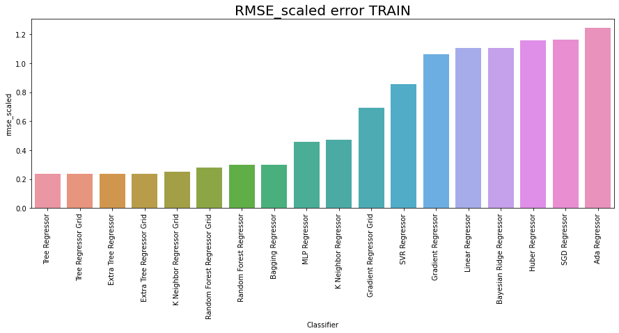

```python
plt.figure(figsize=(15,5))
a = scores_train.sort_values(by = 'rmse_scaled')
p = sns.barplot(x = a.Classifier, y = a.rmse_scaled)
p = plt.xticks(rotation=90)
plt.title("RMSE_scaled error TRAIN", size=20)
```

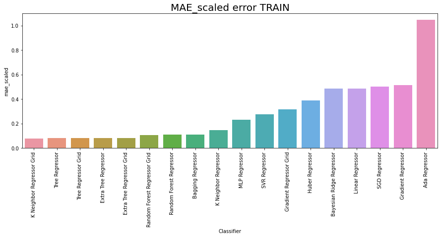

```python
plt.figure(figsize=(15,5))
a = scores_train.sort_values(by = 'mae_scaled')
p = sns.barplot(x = a.Classifier, y = a.mae_scaled)
p = plt.xticks(rotation=90)
plt.title("MAE_scaled error TRAIN", size=20)
```

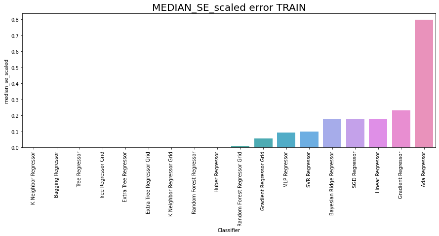

```python
plt.figure(figsize=(15,5))
a = scores_train.sort_values(by = 'median_se_scaled')
p = sns.barplot(x = a.Classifier, y = a.median_se_scaled)
p = plt.xticks(rotation=90)
plt.title("MEDIAN_SE_scaled error TRAIN", size=20)
```

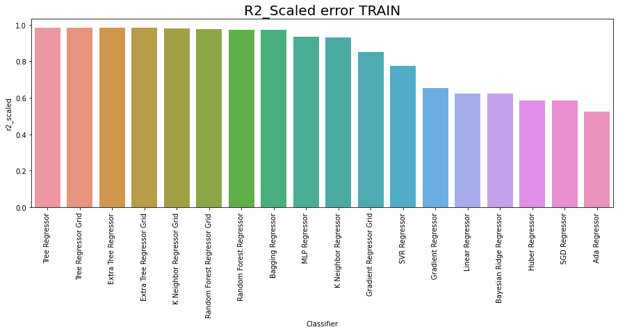

```python
plt.figure(figsize=(15,5))
a = scores_train.sort_values(by = 'r2_scaled', ascending = False)
p = sns.barplot(x = a.Classifier, y = a.r2_scaled)
p = plt.xticks(rotation=90)
plt.title("R2_Scaled error TRAIN", size=20)
```

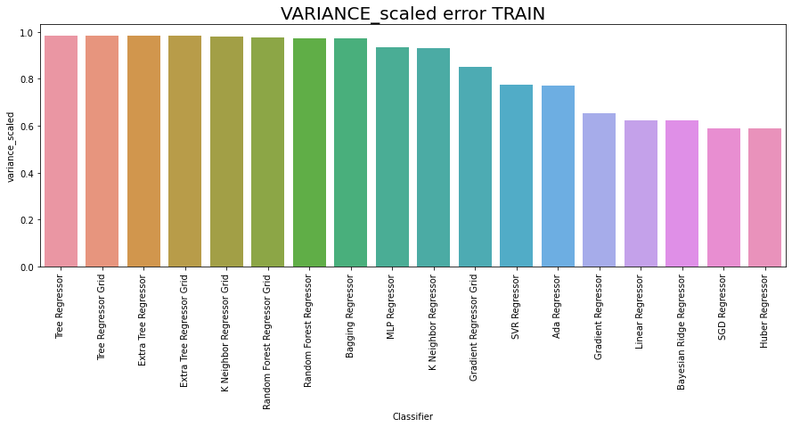

```python
plt.figure(figsize=(15,5))
a = scores_train.sort_values(by = 'variance_scaled', ascending = False)
p = sns.barplot(x = a.Classifier, y = a.variance_scaled)
p = plt.xticks(rotation=90)
plt.title("VARIANCE_scaled error TRAIN", size=20)
```

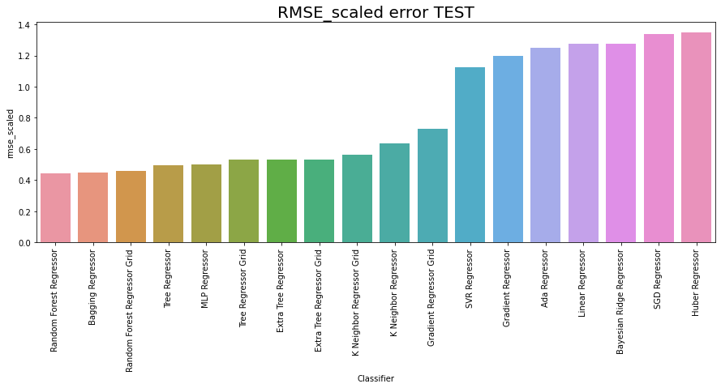

```python
plt.figure(figsize=(15,5))
a = scores_test.sort_values(by = 'rmse_scaled')
p = sns.barplot(x = a.Classifier, y = a.rmse_scaled)
p = plt.xticks(rotation=90)
plt.title("RMSE_scaled error TEST", size=20)
```

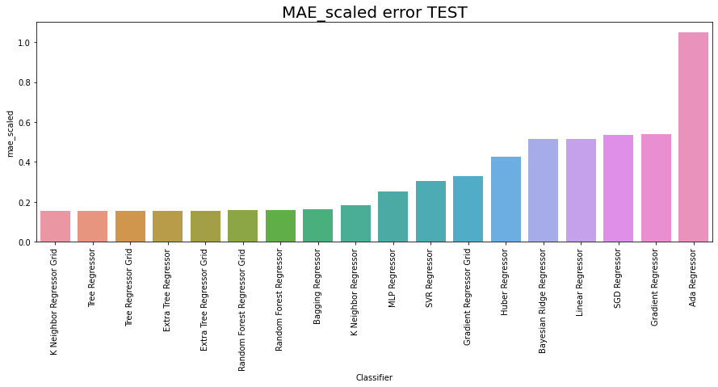

```python
plt.figure(figsize=(15,5))
a = scores_test.sort_values(by = 'mae_scaled')
p = sns.barplot(x = a.Classifier, y = a.mae_scaled)
p = plt.xticks(rotation=90)
plt.title("MAE_scaled error TEST", size=20)
```

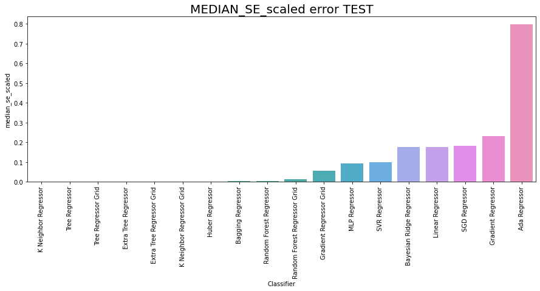

```python
plt.figure(figsize=(15,5))
a = scores_test.sort_values(by = 'median_se_scaled')
p = sns.barplot(x = a.Classifier, y = a.median_se_scaled)
p = plt.xticks(rotation=90)
plt.title("MEDIAN_SE_scaled error TEST", size=20)
```

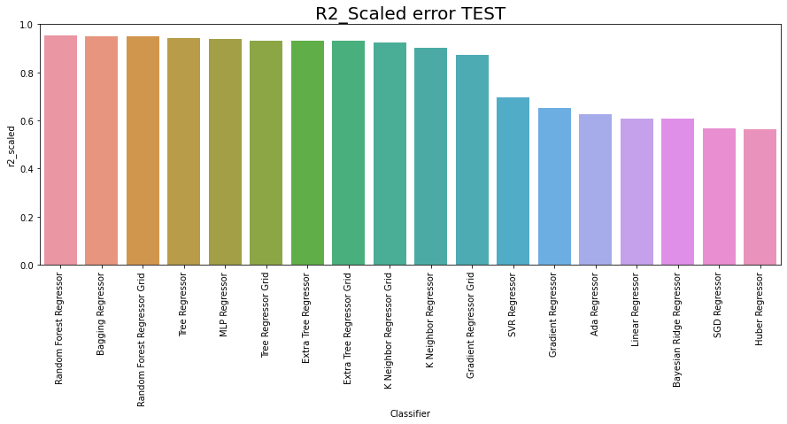

```python
plt.figure(figsize=(15,5))
a = scores_test.sort_values(by = 'r2_scaled', ascending = False)
p = sns.barplot(x = a.Classifier, y = a.r2_scaled)
p = plt.xticks(rotation=90)
plt.title("R2_Scaled error TEST", size=20)
```

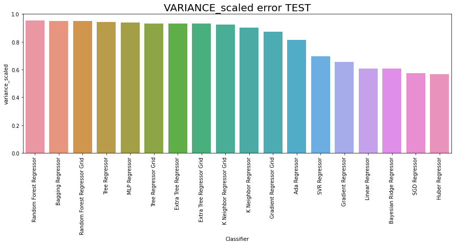

```python
plt.figure(figsize=(15,5))
a = scores_test.sort_values(by = 'variance_scaled', ascending = False)
p = sns.barplot(x = a.Classifier, y = a.variance_scaled)
p = plt.xticks(rotation=90)
plt.title("VARIANCE_scaled error TEST", size=20)
```

I peggiori sempre in termini di r2 ed errori sono Hubner Regressor, SGD Regressor ed anche Ada Regressor.

Di seguito è riportato un confronto tra gli errori commessi sul train e test set, considerando le metriche rmse e r2.

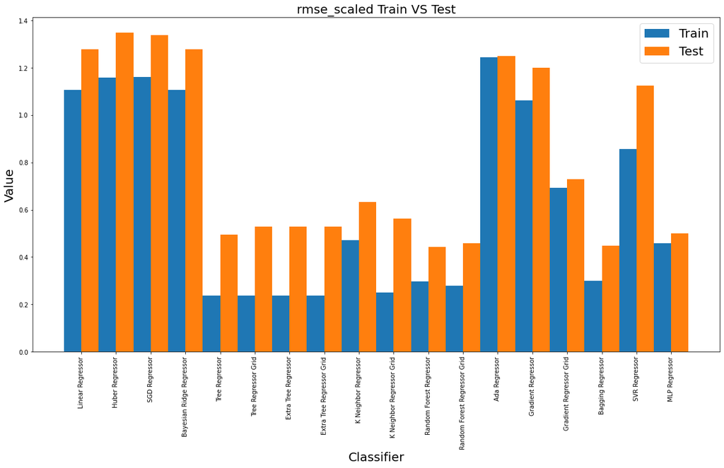

```python
train_rmse = scores_train.rmse_scaled.values.tolist()
test_rmse = scores_test.rmse_scaled.values.tolist()

fig, ax = plt.subplots(figsize=(20,10))
width = 0.50
i = np.arange(len(train_rmse))
train_bars = ax.bar(i, train_rmse , width,)
test_bars = ax.bar(i+width, test_rmse , width)

ax.set_xlabel("Classifier",fontsize=20)

ax.set_ylabel('Value',fontsize=20)
ax.set_title('rmse_scaled Train VS Test',fontsize=20)
ax.set_xticklabels(scores_train.Classifier, rotation = 90)
ax.set_xticks(i + width / 2)

ax.legend((train_bars,test_bars),('Train','Test'),fontsize=20)
plt.show()
```

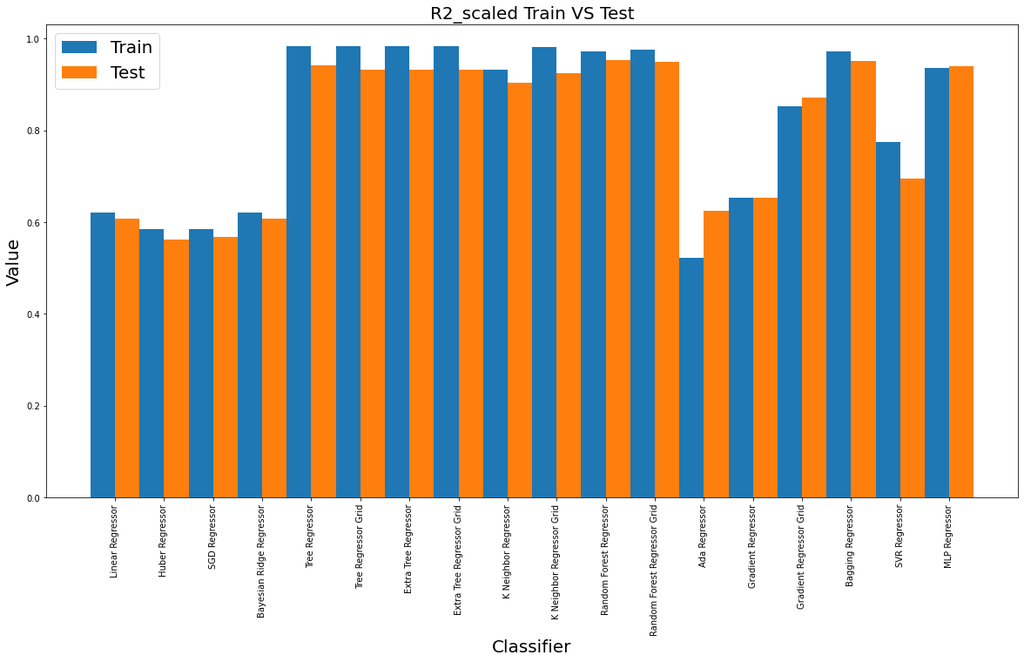

```python
train_r2 = scores_train.r2_scaled.values.tolist()
test_r2 = scores_test.r2_scaled.values.tolist()

fig, ax = plt.subplots(figsize=(20,10))
width = 0.50
i = np.arange(len(train_r2))
train_bars = ax.bar(i, train_r2 , width,)
test_bars = ax.bar(i+width, test_r2 , width)

ax.set_xlabel("Classifier",fontsize=20)

ax.set_ylabel('Value',fontsize=20)
ax.set_title('R2_scaled Train VS Test',fontsize=20)
ax.set_xticklabels(scores_train.Classifier, rotation = 90)
ax.set_xticks(i + width / 2)

ax.legend((train_bars,test_bars),('Train','Test'),fontsize=20)
plt.show()
```

Gli algoritmi che performano meglio sono Random Forest, Bagging, Random Forest grid, Tree, MLP.

Di seguito si sfruttano le funzioni compute_performance_inverse_train e compute_performance_inverse_test attraverso le quali si vuole far ritornare i valori prima scalati a quelli originali, si sfrutta la funzione InverseTransform(). Viene svolta lo stesso tipo di analisi anche per le metriche riportate ai valori reali.

```python
score_dict_train = compute_performance_inverse_train(regressors,names,X_train,y_train)
score_df_train = pd.DataFrame(score_dict_train)
score_df_train
```

|  | Classifier | rmse | variance | mae | median_se | r2 |
| --- | --- | --- | --- | --- | --- | --- |
| 0 | Linear Regressor | 44510.51338369 | 0.62165668 | 19485.64976525 | 7130.54000854 | 0.62165668 |
| 1 | Huber Regressor | 46582.97080965 | 0.58867119 | 15673.15451840 | 3.11000574 | 0.58560431 |
| 2 | SGD Regressor | 46679.29993761 | 0.58908109 | 20212.34271591 | 7106.99618511 | 0.58388868 |
| 3 | Bayesian Ridge Regressor | 44510.74702670 | 0.62165271 | 19452.21048803 | 7089.58800021 | 0.62165271 |
| 4 | Tree Regressor | 9576.33145701 | 0.98248705 | 3261.53230294 | 0.00000000 | 0.98248705 |
| 5 | Tree Regressor Grid | 9576.33145701 | 0.98248705 | 3261.53230294 | 0.00000000 | 0.98248705 |
| 6 | Extra Tree Regressor | 9576.33145701 | 0.98248705 | 3261.53230294 | 0.00000000 | 0.98248705 |
| 7 | Extra Tree Regressor Grid | 9576.33145701 | 0.98248705 | 3261.53230294 | 0.00000000 | 0.98248705 |
| 8 | K Neighbor Regressor | 18980.98182993 | 0.93124742 | 5938.44100759 | 0.00000000 | 0.93119845 |
| 9 | K Neighbor Regressor Grid | 10059.70247397 | 0.98068151 | 3090.98606649 | 0.00000000 | 0.98067448 |
| 10 | Radius Neighbor Regressor | 13689.07380683 | 0.96426116 | 5638.19018897 | 913.52272727 | 0.96421434 |
| 11 | Random Forest Regressor | 11948.81769527 | 0.97273499 | 4397.71444188 | 0.00000000 | 0.97273467 |
| 12 | Random Forest Regressor Grid | 11173.32158712 | 0.97615997 | 4287.04498393 | 401.95000000 | 0.97615895 |
| 13 | Ada Regressor | 49991.59747481 | 0.77190303 | 42014.25000137 | 32032.28169957 | 0.52274016 |
| 14 | Gradient Regressor | 42654.05336368 | 0.65255867 | 20656.87643124 | 9281.37634318 | 0.65255867 |
| 15 | Gradient Regressor Grid | 27863.21224430 | 0.85174026 | 12662.30275005 | 2303.76346848 | 0.85174026 |
| 16 | Bagging Regressor | 12033.35177376 | 0.97234766 | 4404.07322837 | 0.00000000 | 0.97234752 |
| 17 | SVR Regressor | 34382.77031756 | 0.77588873 | 11130.83708511 | 3928.34571857 | 0.77424229 |
| 18 | MLP Regressor | 18437.69305538 | 0.93510835 | 9297.71968460 | 3712.02946991 | 0.93508067 |

```python
score_dict_test = compute_performance_inverse_test(regressors,names,X_test,y_test)
score_df_test = pd.DataFrame(score_dict_test)
score_df_test
```

|  | Classifier | rmse | variance | mae | median_se | r2 |
| --- | --- | --- | --- | --- | --- | --- |
| 0 | Linear Regressor | 51324.04000640 | 0.60717508 | 20655.30252648 | 7130.54000854 | 0.60702833 |
| 1 | Huber Regressor | 54135.35441272 | 0.56711989 | 17068.47855583 | 3.21249097 | 0.56279861 |
| 2 | SGD Regressor | 53791.16413635 | 0.57423950 | 21467.45601414 | 7265.90399707 | 0.56834035 |
| 3 | Bayesian Ridge Regressor | 51328.59995404 | 0.60710586 | 20621.99368093 | 7074.71124194 | 0.60695850 |
| 4 | Tree Regressor | 19887.77000421 | 0.94102548 | 6174.93829340 | 0.00000000 | 0.94099460 |
| 5 | Tree Regressor Grid | 21288.02003209 | 0.93242452 | 6289.03403580 | 0.00000000 | 0.93239324 |
| 6 | Extra Tree Regressor | 21288.02003209 | 0.93242452 | 6289.03403580 | 0.00000000 | 0.93239324 |
| 7 | Extra Tree Regressor Grid | 21288.02003209 | 0.93242452 | 6289.03403580 | 0.00000000 | 0.93239324 |
| 8 | K Neighbor Regressor | 25473.27890146 | 0.90336503 | 7387.30799727 | 0.00000000 | 0.90319690 |
| 9 | K Neighbor Regressor Grid | 22621.36247740 | 0.92379882 | 6165.13663573 | 0.00000000 | 0.92365913 |
| 10 | Radius Neighbor Regressor | 12483617403317.53125000 | -22762526065635132.00000000 | 1805423128513.10351562 | 1566.03896104 | -23248796170589140.00000000 |
| 11 | Random Forest Regressor | 17824.49998242 | 0.95262694 | 6437.35979560 | 153.65209805 | 0.95260263 |
| 12 | Random Forest Regressor Grid | 18386.02869661 | 0.94963267 | 6408.66953945 | 465.30868626 | 0.94956925 |
| 13 | Ada Regressor | 50172.73449179 | 0.81260945 | 42114.85369646 | 32032.28169957 | 0.62446094 |
| 14 | Gradient Regressor | 48172.09860627 | 0.65406970 | 21670.93845265 | 9281.37634318 | 0.65381304 |
| 15 | Gradient Regressor Grid | 29315.85402589 | 0.87186141 | 13281.06361745 | 2303.76346848 | 0.87178918 |
| 16 | Bagging Regressor | 18004.24716489 | 0.95166306 | 6475.45293102 | 153.65209805 | 0.95164187 |
| 17 | SVR Regressor | 45232.36305129 | 0.69707749 | 12278.13337465 | 3928.34571857 | 0.69477639 |
| 18 | MLP Regressor | 20144.50220245 | 0.93952706 | 10161.13433342 | 3792.42907611 | 0.93946136 |

```python
scores_train = score_df_train[(score_df_train.Classifier != 'Radius Neighbor Regressor')]
scores_train
```

|  | Classifier | rmse | variance | mae | median_se | r2 |
| --- | --- | --- | --- | --- | --- | --- |
| 0 | Linear Regressor | 44510.51338369 | 0.62165668 | 19485.64976525 | 7130.54000854 | 0.62165668 |
| 1 | Huber Regressor | 46582.97080965 | 0.58867119 | 15673.15451840 | 3.11000574 | 0.58560431 |
| 2 | SGD Regressor | 46679.29993761 | 0.58908109 | 20212.34271591 | 7106.99618511 | 0.58388868 |
| 3 | Bayesian Ridge Regressor | 44510.74702670 | 0.62165271 | 19452.21048803 | 7089.58800021 | 0.62165271 |
| 4 | Tree Regressor | 9576.33145701 | 0.98248705 | 3261.53230294 | 0.00000000 | 0.98248705 |
| 5 | Tree Regressor Grid | 9576.33145701 | 0.98248705 | 3261.53230294 | 0.00000000 | 0.98248705 |
| 6 | Extra Tree Regressor | 9576.33145701 | 0.98248705 | 3261.53230294 | 0.00000000 | 0.98248705 |
| 7 | Extra Tree Regressor Grid | 9576.33145701 | 0.98248705 | 3261.53230294 | 0.00000000 | 0.98248705 |
| 8 | K Neighbor Regressor | 18980.98182993 | 0.93124742 | 5938.44100759 | 0.00000000 | 0.93119845 |
| 9 | K Neighbor Regressor Grid | 10059.70247397 | 0.98068151 | 3090.98606649 | 0.00000000 | 0.98067448 |
| 11 | Random Forest Regressor | 11948.81769527 | 0.97273499 | 4397.71444188 | 0.00000000 | 0.97273467 |
| 12 | Random Forest Regressor Grid | 11173.32158712 | 0.97615997 | 4287.04498393 | 401.95000000 | 0.97615895 |
| 13 | Ada Regressor | 49991.59747481 | 0.77190303 | 42014.25000137 | 32032.28169957 | 0.52274016 |
| 14 | Gradient Regressor | 42654.05336368 | 0.65255867 | 20656.87643124 | 9281.37634318 | 0.65255867 |
| 15 | Gradient Regressor Grid | 27863.21224430 | 0.85174026 | 12662.30275005 | 2303.76346848 | 0.85174026 |
| 16 | Bagging Regressor | 12033.35177376 | 0.97234766 | 4404.07322837 | 0.00000000 | 0.97234752 |
| 17 | SVR Regressor | 34382.77031756 | 0.77588873 | 11130.83708511 | 3928.34571857 | 0.77424229 |
| 18 | MLP Regressor | 18437.69305538 | 0.93510835 | 9297.71968460 | 3712.02946991 | 0.93508067 |

```python
scores_test = score_df_test[(score_df_test.Classifier != 'Radius Neighbor Regressor')]
scores_test
```

|  | Classifier | rmse | variance | mae | median_se | r2 |
| --- | --- | --- | --- | --- | --- | --- |
| 0 | Linear Regressor | 51324.04000640 | 0.60717508 | 20655.30252648 | 7130.54000854 | 0.60702833 |
| 1 | Huber Regressor | 54135.35441272 | 0.56711989 | 17068.47855583 | 3.21249097 | 0.56279861 |
| 2 | SGD Regressor | 53791.16413635 | 0.57423950 | 21467.45601414 | 7265.90399707 | 0.56834035 |
| 3 | Bayesian Ridge Regressor | 51328.59995404 | 0.60710586 | 20621.99368093 | 7074.71124194 | 0.60695850 |
| 4 | Tree Regressor | 19887.77000421 | 0.94102548 | 6174.93829340 | 0.00000000 | 0.94099460 |
| 5 | Tree Regressor Grid | 21288.02003209 | 0.93242452 | 6289.03403580 | 0.00000000 | 0.93239324 |
| 6 | Extra Tree Regressor | 21288.02003209 | 0.93242452 | 6289.03403580 | 0.00000000 | 0.93239324 |
| 7 | Extra Tree Regressor Grid | 21288.02003209 | 0.93242452 | 6289.03403580 | 0.00000000 | 0.93239324 |
| 8 | K Neighbor Regressor | 25473.27890146 | 0.90336503 | 7387.30799727 | 0.00000000 | 0.90319690 |
| 9 | K Neighbor Regressor Grid | 22621.36247740 | 0.92379882 | 6165.13663573 | 0.00000000 | 0.92365913 |
| 11 | Random Forest Regressor | 17824.49998242 | 0.95262694 | 6437.35979560 | 153.65209805 | 0.95260263 |
| 12 | Random Forest Regressor Grid | 18386.02869661 | 0.94963267 | 6408.66953945 | 465.30868626 | 0.94956925 |
| 13 | Ada Regressor | 50172.73449179 | 0.81260945 | 42114.85369646 | 32032.28169957 | 0.62446094 |
| 14 | Gradient Regressor | 48172.09860627 | 0.65406970 | 21670.93845265 | 9281.37634318 | 0.65381304 |
| 15 | Gradient Regressor Grid | 29315.85402589 | 0.87186141 | 13281.06361745 | 2303.76346848 | 0.87178918 |
| 16 | Bagging Regressor | 18004.24716489 | 0.95166306 | 6475.45293102 | 153.65209805 | 0.95164187 |
| 17 | SVR Regressor | 45232.36305129 | 0.69707749 | 12278.13337465 | 3928.34571857 | 0.69477639 |
| 18 | MLP Regressor | 20144.50220245 | 0.93952706 | 10161.13433342 | 3792.42907611 | 0.93946136 |

anche in questo caso viene rimosso Radius Neighbor Regressor e si procede con la visualizzazione delle metriche.

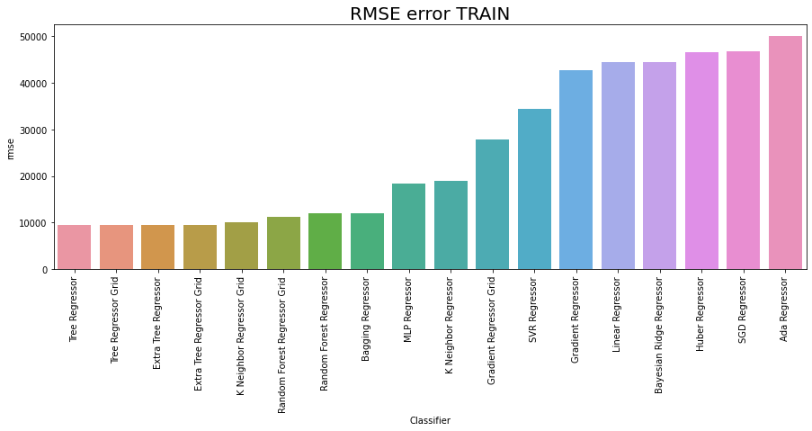

```python
plt.figure(figsize=(15,5))
a = scores_train.sort_values(by = 'rmse')
p = sns.barplot(x = a.Classifier, y = a.rmse)
p = plt.xticks(rotation=90)
plt.title("RMSE error TRAIN", size=20)
```